# Exploratroy Analysis: Gene Age and Stress Adaptation: A Comparative Transcriptomic Analysis of Phosphate Starvation in Budding Yeast

Joshua Ayelazuno

2025-10-20

Goal. Quantify how phosphate-limitation (-Pi) transcriptional responses are distributed across orthology classes (single-core, multi-core, non-core) in four yeasts—S. cerevisiae (Scer), C. glabrata (Cgla), C. albicans (Calb), and K. lactis (Klac)—and test whether specific classes are enriched for differentially expressed genes (DEGs).

Biological question. Are stress-responsive genes preferentially drawn from duplicated (multi-copy) or lineage-specific (non-core) gene sets, as suggested by Doughty et al., or from conserved single-copy (single-core) genes? Do patterns differ by species?

Set output locations *_results paths point to where species-specific DE/summary CSVs will be written. *_plots paths point to where figures for each species will be saved.

Using here() keeps paths project-relative for reproducibility.

Load orthology mapping orthogroups reads the consolidated OrthoFinder table (species_orthology.tsv). This file provides per-species gene lists per orthogroup and is later used to assign core status (single-core, multi-core, non-core) to each gene.

```r
Scer <- read_tsv(here("06.results", "Scer", "Calb_renamed_counts.tsv"), show_col_types = FALSE)
```

[output not shown]

Differential gene expression analysis with DESeq2

Goal. Estimate gene-level differential expression between control (t0000) and treatment (t0060) for each species, collapsing technical replicates, and produce (i) a full results table for enrichment “universe” analyses and (ii) clean DEG sets (all / up / down) plus QC plots.

What this chunk does (re-usable for any species): Select samples for the contrast. Keep only columns matching t0000|t0060; coerce counts to integers; set gene_id as rownames.

Build sample metadata and handle replicates. Derive condition from column names (untreated, treated). Create sample IDs to group technical runs (e.g., 1–4) and set run to the original column names.

Construct DESeq2 object and collapse technical replicates. DESeqDataSetFromMatrix(…, design = ~ condition) → model matrix. collapseReplicates() sums counts within each biological sample across runs. Re-apply the condition labels to the collapsed columns.

Fit the model and shrink effect sizes. DESeq() fits NB GLMs. results(…, contrast = c(“condition”,“treated”,“untreated”)) extracts treated vs control. lfcShrink(…, type = “apeglm”) returns stabilized log2FCs for reporting/plots.

Export the full universe for GO/topGO. Convert to a data frame, clean gene_id (e.g., drop gene- prefix), and write _DE_topGo.csv (all tested genes, not just significant).

Call significant DEGs (and split by direction). Apply thresholds padj < 0.01 and |log2FoldChange| > 1. Split into resSig*_up (log2FC > 0) and resSig*_down (log2FC < 0). Write three CSVs (all / up / down) and simple ID lists (*_UP_ids.txt, *_DOWN_ids.txt).

QC & exploratory visualizations. rlog() → PCA plot to confirm replicate clustering and treatment separation. Histograms of raw p-values and FDR to check multiple-testing behavior. MA plot to inspect mean–FC trends. Volcano plot with LFC/FDR cut lines to visualize significant genes.

Notes & conventions. Contrast direction is treated vs untreated; positive log2FC means induced in treatment.  
Collapsing technical replicates improves variance estimates; biological replicates remain separate in the model. Keep this workflow identical across species; only the input count matrix and output paths change.

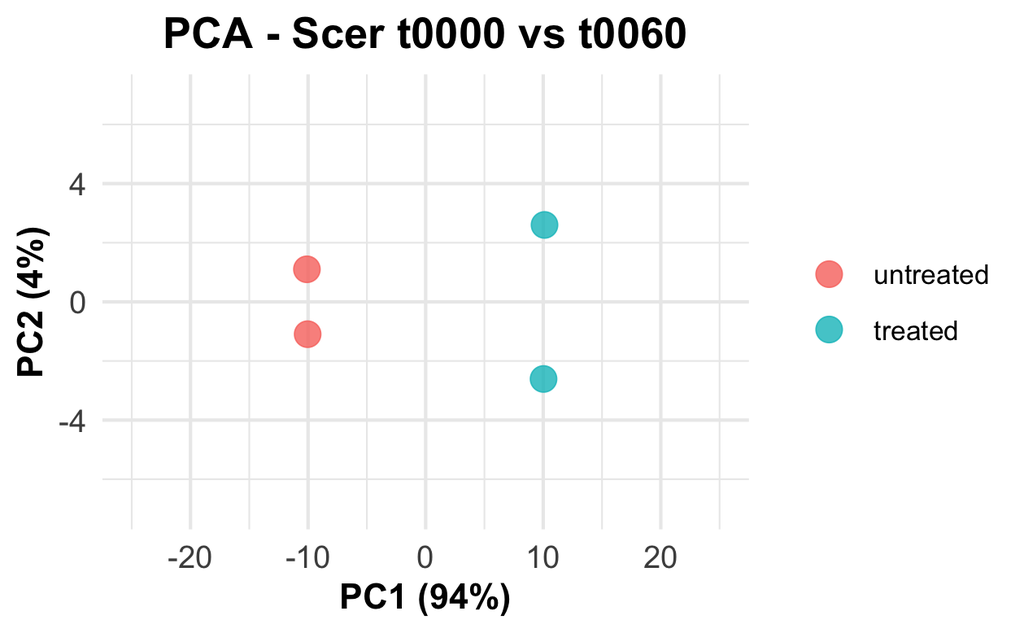

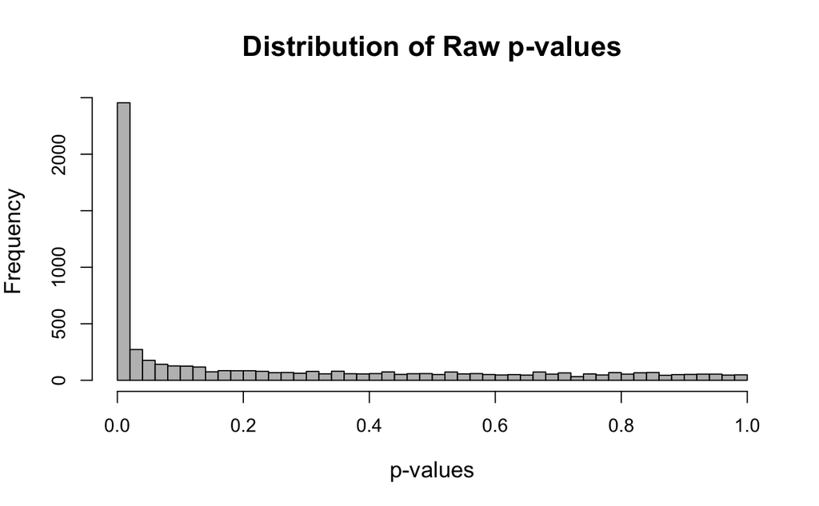

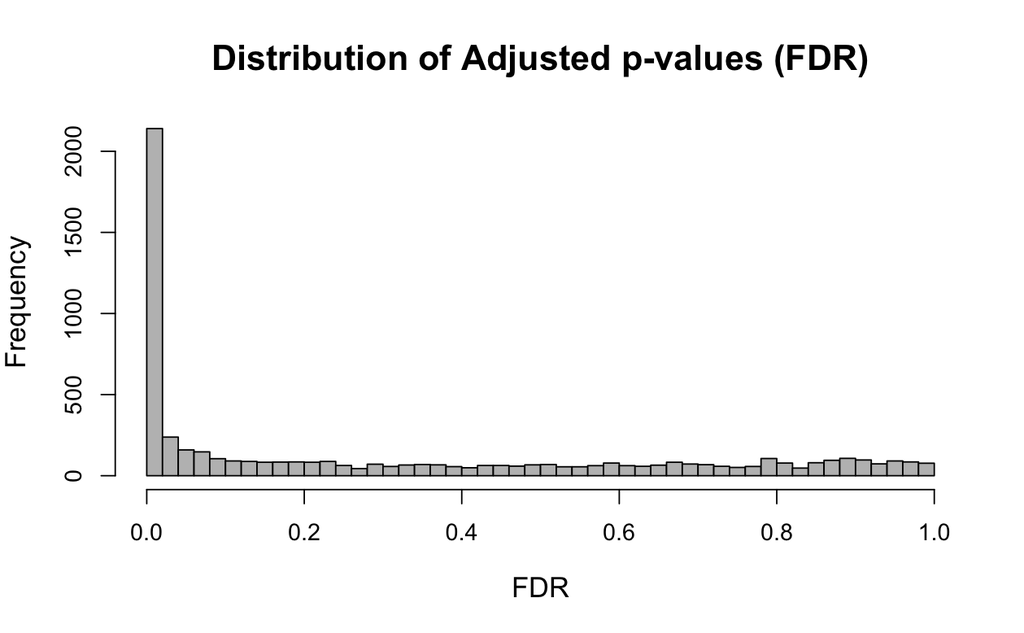

```r
ScerPCA1
#ggsave(filename = file.path(Scer_plots, "PCA_Scer_t0000_vs_t0060.pdf"),
       #plot = ScerPCA1, width = 8, height = 6)

# p-value histogram
#pdf(file.path(Scer_plots, "Histogram_pvalue_Scer.pdf"))
hist(resLFCsc$pvalue,
     breaks = 50, col = "grey",
     main = "Distribution of Raw p-values",
     xlab = "p-values", ylab = "Frequency",
     cex.main = 1.5, cex.lab = 1.2)

#dev.off()

# Adjusted p-value histogram
#pdf(file.path(Scer_plots, "Histogram_padj_Scer.pdf"))
hist(resLFCsc$padj,
     breaks = 50, col = "grey",
     main = "Distribution of Adjusted p-values (FDR)",
     xlab = "FDR", ylab = "Frequency",
     cex.main = 1.5, cex.lab = 1.2)
```

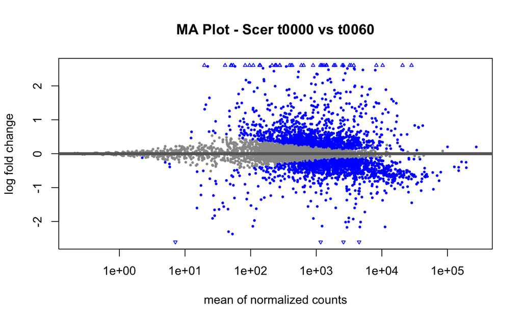

```r
#dev.off()

# MA plot
#pdf(file.path(Scer_plots, "MA_plot_Scer.pdf"))
plotMA(resLFCsc, main = "MA Plot - Scer t0000 vs t0060", cex = 0.5)
```

```r
#dev.off()

# Volcano plot
lfc_threshold <- 1
pval_threshold <- 0.01

tab <- data.frame(
  logFC = resLFCsc$log2FoldChange,
  negLogPval = -log10(resLFCsc$padj)
)

sig <- with(tab, abs(logFC) > lfc_threshold & negLogPval > -log10(pval_threshold))
#pdf(file.path(Scer_plots, "Volcano_plot_Scer.pdf"))
plot(tab, pch = 16, cex = 0.5,
     xlab = expression(bold(log[2]~fold~change)),
     ylab = expression(bold(-log[10]~FDR)),
     main = "Volcano Plot - Scer t0000 vs t0060")
points(tab[sig, ], col = "red", pch = 16, cex = 0.6)
```

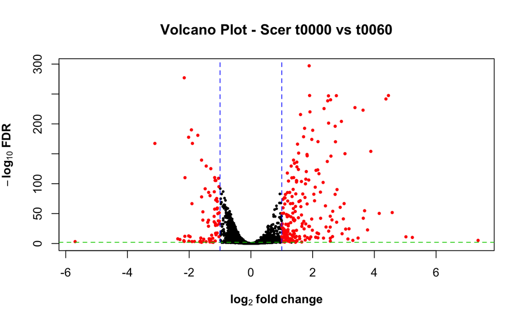

```r
abline(h = -log10(pval_threshold), col = "green3", lty = 2)
abline(v = c(-lfc_threshold, lfc_threshold), col = "blue", lty = 2)
```

```r
#dev.off()
```

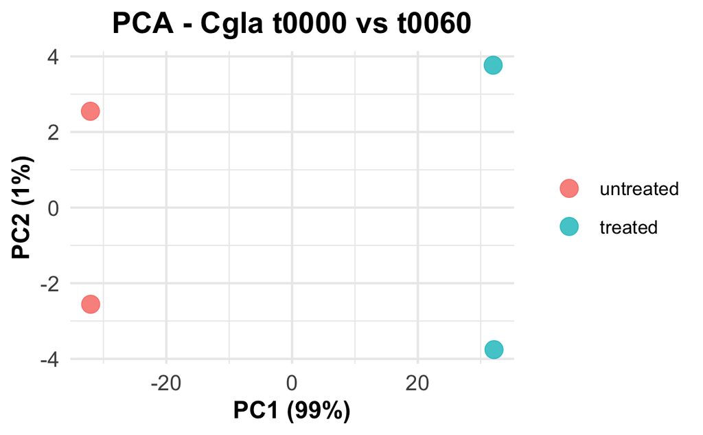

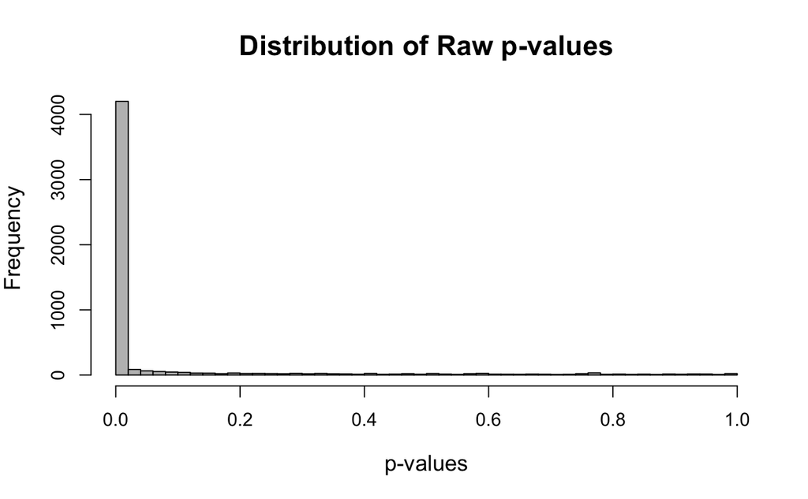

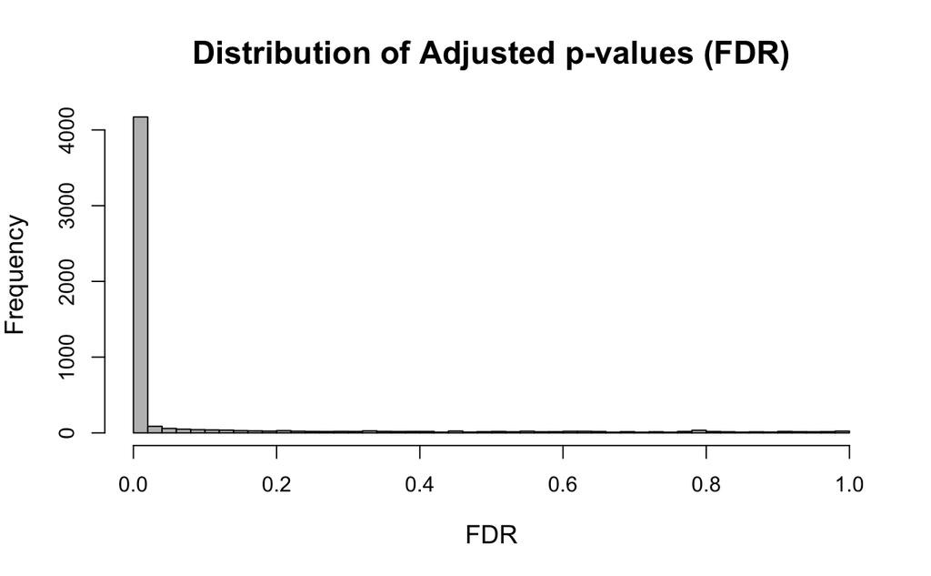

```r
CglaPCA1

# Save new plot
#ggsave(filename = file.path(Cgla_plots, "PCA_Cgla_t0000_vs_t0060_adjusted.pdf"),
       #plot = CglaPCA1, width = 8, height = 6)


# p-value histogram
#pdf(file.path(Cgla_plots, "Histogram_pvalue_Cgla.pdf"))
hist(resLFCcg$pvalue, breaks = 50, col = "grey",
     main = "Distribution of Raw p-values",
     xlab = "p-values", ylab = "Frequency",
     cex.main = 1.5, cex.lab = 1.2)

#dev.off()

# adjusted p-value histogram
#pdf(file.path(Cgla_plots, "Histogram_padj_Cgla.pdf"))
hist(resLFCcg$padj, breaks = 50, col = "grey",
     main = "Distribution of Adjusted p-values (FDR)",
     xlab = "FDR", ylab = "Frequency",
     cex.main = 1.5, cex.lab = 1.2)
```

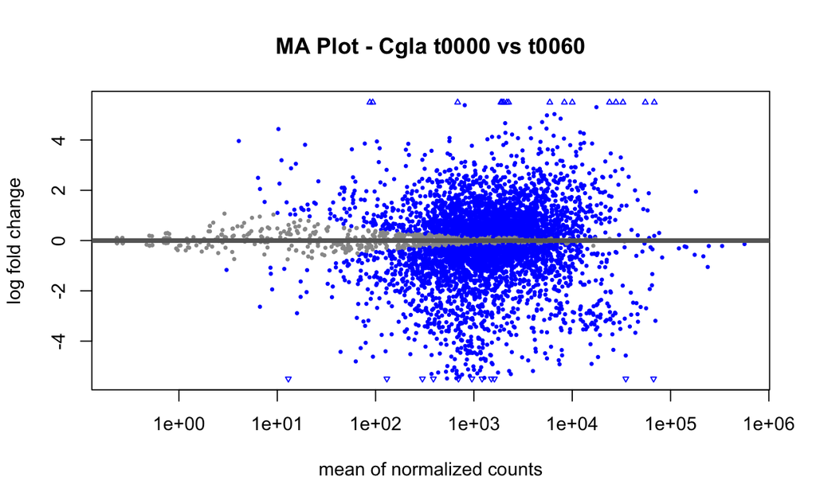

```r
#dev.off()

# MA plot
#pdf(file.path(Cgla_plots, "MA_plot_Cgla.pdf"))
plotMA(resLFCcg, main = "MA Plot - Cgla t0000 vs t0060", cex = 0.5)
```

```r
#dev.off()

# Volcano plot
lfc_threshold <- 1
pval_threshold <- 0.01

tab_cg <- data.frame(
  logFC = resLFCcg$log2FoldChange,
  negLogPval = -log10(resLFCcg$padj)
)

sig_cg <- with(tab_cg, abs(logFC) > lfc_threshold & negLogPval > -log10(pval_threshold))

#pdf(file.path(Cgla_plots, "Volcano_plot_Cgla.pdf"))
plot(tab_cg, pch = 16, cex = 0.5,
     xlab = expression(bold(log[2]~fold~change)),
     ylab = expression(bold(-log[10]~FDR)),
     main = "Volcano Plot - Cgla t0000 vs t0060")
points(tab_cg[sig_cg, ], col = "red", pch = 16, cex = 0.6)
```

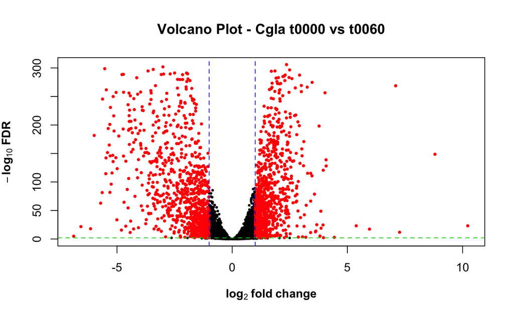

```r
abline(h = -log10(pval_threshold), col = "green3", lty = 2)
abline(v = c(-lfc_threshold, lfc_threshold), col = "blue", lty = 2)
```

```r
#dev.off()
```

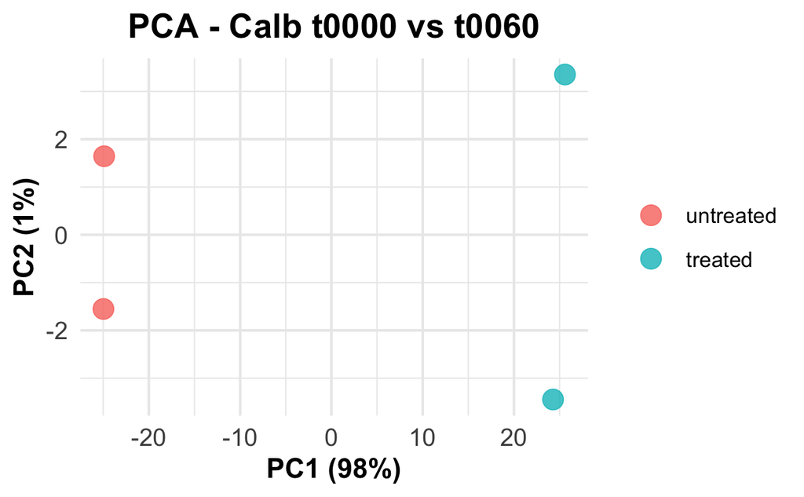

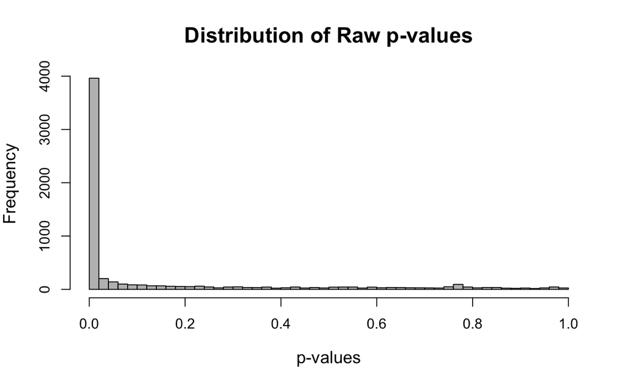

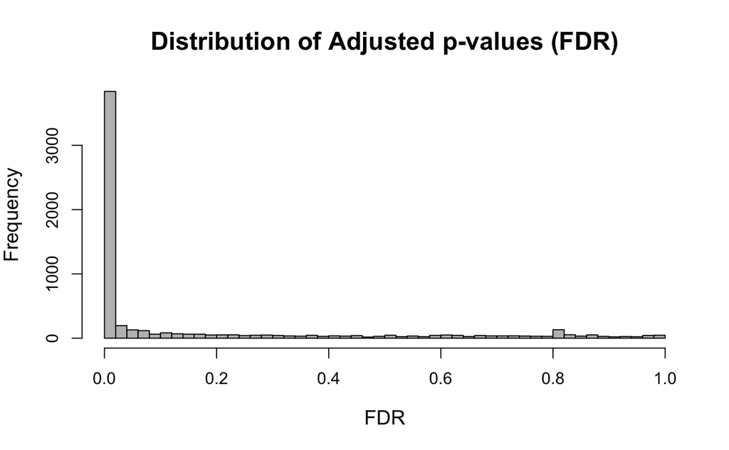

```r
CalbPCA1

#ggsave(filename = file.path(Calb_plots, "PCA_Calb_t0000_vs_t0060.pdf"),
       #plot = CalbPCA1, width = 8, height = 6)

# p-value histogram
#pdf(file.path(Calb_plots, "Histogram_pvalue_Calb.pdf"))
hist(resLFCcalb$pvalue, breaks = 50, col = "grey",
     main = "Distribution of Raw p-values",
     xlab = "p-values", ylab = "Frequency",
     cex.main = 1.5, cex.lab = 1.2)

#dev.off()

# adjusted p-value histogram
#pdf(file.path(Calb_plots, "Histogram_padj_Calb.pdf"))
hist(resLFCcalb$padj, breaks = 50, col = "grey",
     main = "Distribution of Adjusted p-values (FDR)",
     xlab = "FDR", ylab = "Frequency",
     cex.main = 1.5, cex.lab = 1.2)
```

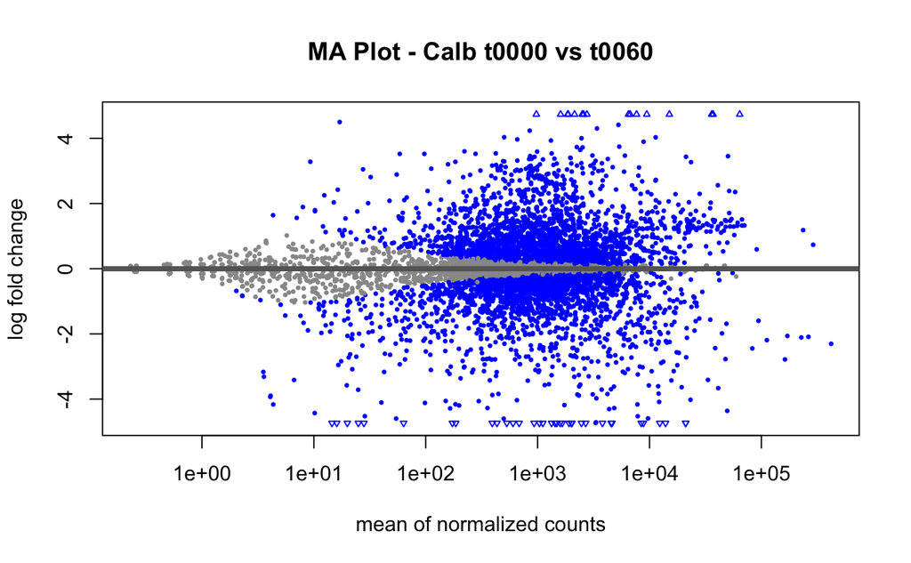

```r
#dev.off()

# MA plot
#pdf(file.path(Calb_plots, "MA_plot_Calb.pdf"))
plotMA(resLFCcalb, main = "MA Plot - Calb t0000 vs t0060", cex = 0.5)
```

```r
#dev.off()

# Volcano plot
lfc_threshold <- 1
pval_threshold <- 0.01

tab_calb <- data.frame(
  logFC = resLFCcalb$log2FoldChange,
  negLogPval = -log10(resLFCcalb$padj)
)

sig_calb <- with(tab_calb, abs(logFC) > lfc_threshold & negLogPval > -log10(pval_threshold))

#pdf(file.path(Calb_plots, "Volcano_plot_Calb.pdf"))
plot(tab_calb, pch = 16, cex = 0.5,
     xlab = expression(bold(log[2]~fold~change)),
     ylab = expression(bold(-log[10]~FDR)),
     main = "Volcano Plot - Calb t0000 vs t0060")
points(tab_calb[sig_calb, ], col = "red", pch = 16, cex = 0.6)
```

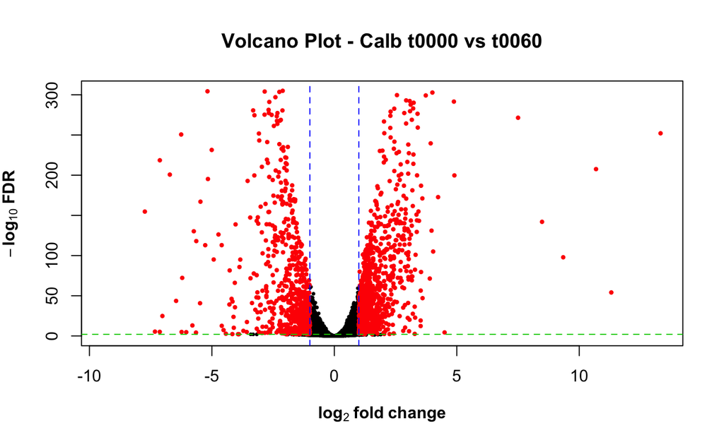

```r
abline(h = -log10(pval_threshold), col = "green3", lty = 2)
abline(v = c(-lfc_threshold, lfc_threshold), col = "blue", lty = 2)
```

```r
#dev.off()
```

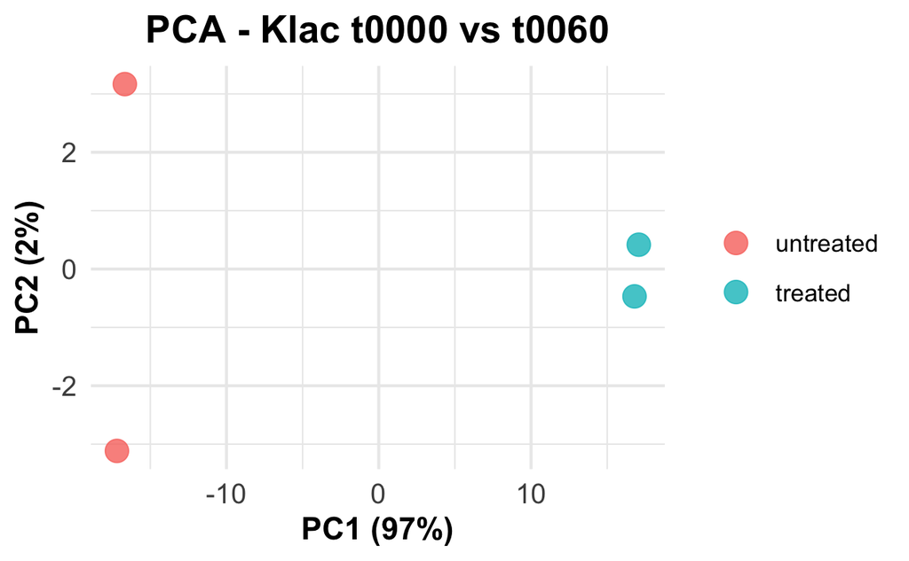

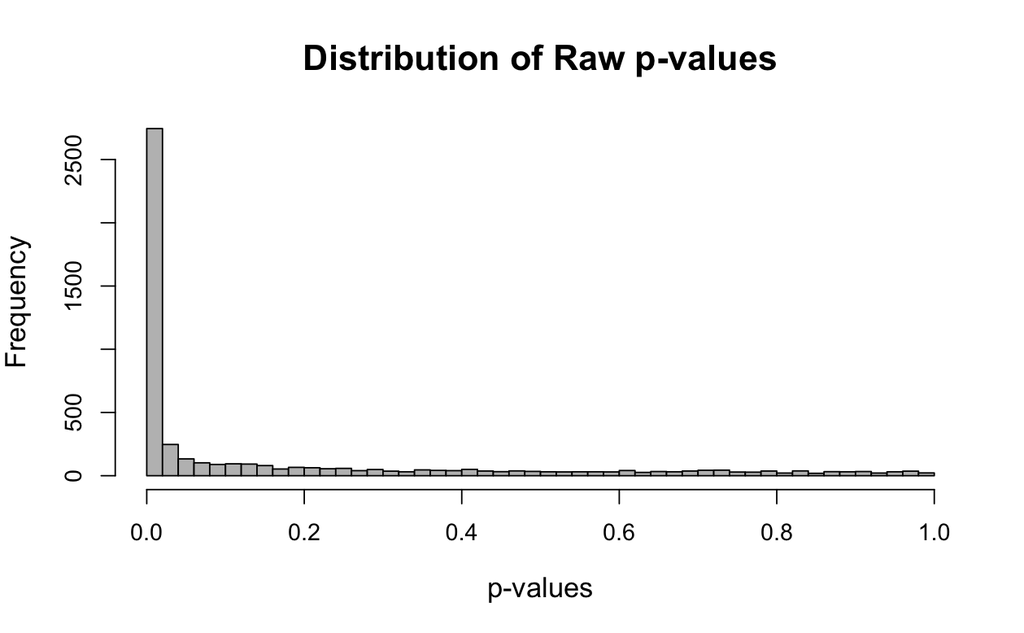

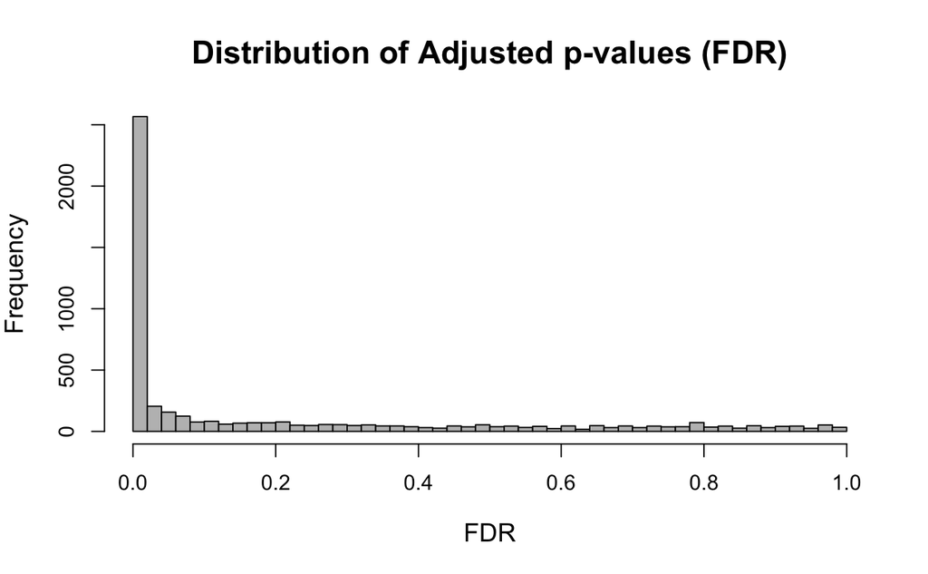

```r
KlacPCA1
#ggsave(filename = file.path(Klac_plots, "PCA_Klac_t0000_vs_t0060.pdf"),
       #plot = KlacPCA1, width = 8, height = 6)

# Histograms
#pdf(file.path(Klac_plots, "Histogram_pvalue_Klac.pdf"))
hist(resLFCklac$pvalue, breaks = 50, col = "grey",
     main = "Distribution of Raw p-values",
     xlab = "p-values", ylab = "Frequency",
     cex.main = 1.5, cex.lab = 1.2)

#dev.off()

#pdf(file.path(Klac_plots, "Histogram_padj_Klac.pdf"))
hist(resLFCklac$padj, breaks = 50, col = "grey",
     main = "Distribution of Adjusted p-values (FDR)",
     xlab = "FDR", ylab = "Frequency",
     cex.main = 1.5, cex.lab = 1.2)
```

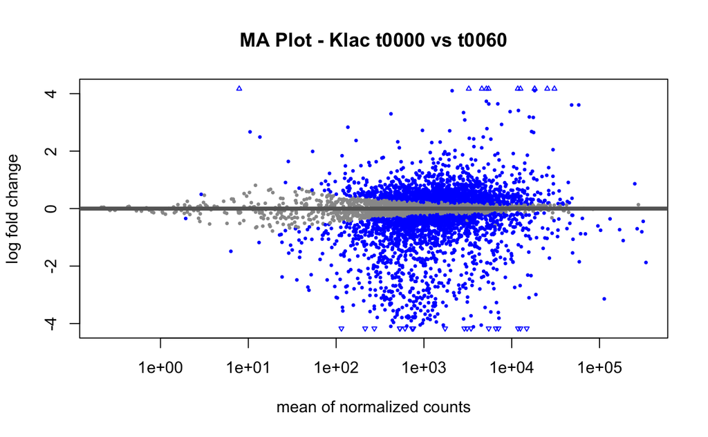

```r
#dev.off()

# MA plot
#pdf(file.path(Klac_plots, "MA_plot_Klac.pdf"))
plotMA(resLFCklac, main = "MA Plot - Klac t0000 vs t0060", cex = 0.5)
```

```r
#dev.off()

# Volcano plot
lfc_threshold <- 1
pval_threshold <- 0.01

tab_klac <- data.frame(
  logFC = resLFCklac$log2FoldChange,
  negLogPval = -log10(resLFCklac$padj)
)

sig_klac <- with(tab_klac, abs(logFC) > lfc_threshold & negLogPval > -log10(pval_threshold))

#pdf(file.path(Klac_plots, "Volcano_plot_Klac.pdf"))
plot(tab_klac, pch = 16, cex = 0.5,
     xlab = expression(bold(log[2]~fold~change)),
     ylab = expression(bold(-log[10]~FDR)),
     main = "Volcano Plot - Klac t0000 vs t0060")
points(tab_klac[sig_klac, ], col = "red", pch = 16, cex = 0.6)
```

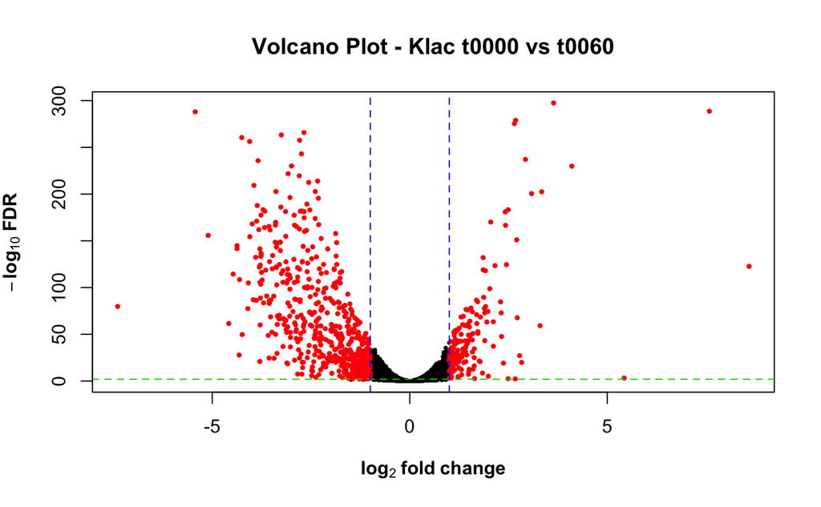

```r
abline(h = -log10(pval_threshold), col = "green3", lty = 2)
abline(v = c(-lfc_threshold, lfc_threshold), col = "blue", lty = 2)
```

```r
#dev.off()
```

Count DEGs by direction. Uses your already filtered DE tables (resSigsc, resSigcg, resSigca, resSigkl).

Defines UP as log2FC > 0, DOWN as log2FC < 0. Assumes significance was called with padj < 0.01 and |log2FC| > 1. If you’re replicating Doughty’s Fig. 1c (UP-only), adjust accordingly.

Summarize and plot totals. Builds deg_summary (UP, DOWN, Total) across species. Converts to long format and makes a grouped bar chart (Upregulated vs Downregulated) per species.

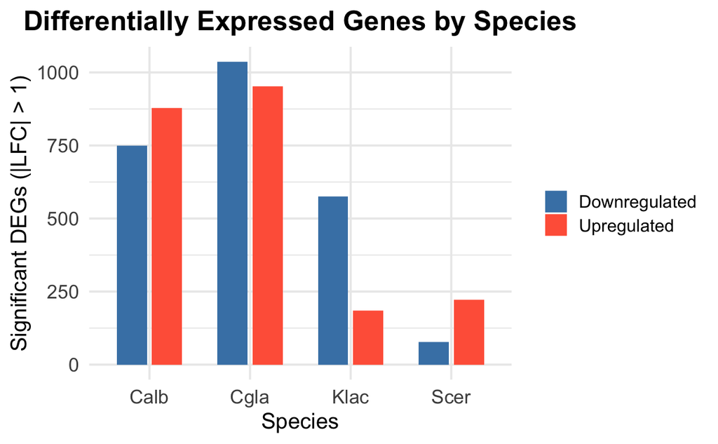

Goal (functional enrichment with topGO)

Identify Biological Process (BP) Gene Ontology terms enriched among DESeq2-tested genes for each species (Scer, Cgla, Calb, Klac), using a consistent pipeline so results are comparable across species and suitable for cross-species summaries.

What this chunk does

Set up: load packages, create per-species plot/output folders, and define small helper functions to save QC plots (p-value histograms, GO term size histograms), barplots comparing topGO algorithms, and GO DAG snapshots.

Universe & scores: for each species, take the full DESeq table (*_topGo.csv), set gene-level scores to the DESeq p-value (NAs → 1), and define the selection function p < 0.01. Run topGO per species: build topGOdata (BP, nodeSize=10), run multiple algorithms (classic, elim, weight01, plus KS for Scer), generate a ranked results table, and write it to disk. QC & visualization: save p-value and GO size histograms, an algorithm comparison barplot (−log10 p across classic/elim/weight01), and a GO DAG image of the top nodes. Sanity checks: print annotation coverage (how many genes in the universe are annotated), counts of p=1 terms, distribution of term sizes, and proportion of terms with zero significant genes. Cross-species summary: combine significant terms (weight01 < 0.05) across species into a presence/absence matrix and save for downstream comparison.

Why this structure? Using the complete DESeq universe (not just significant genes) avoids selection bias, topGO’s elim/weight01 reduce GO hierarchy dependencies, and the standardized plotting/QC makes differences across species interpretable and reproducible.

```r
############ functional analysis with topGo
# library(topGO)
# library(biomaRt)
# library(org.Sc.sgd.db)
# library(GO.db)
# library(ggplot2)
# library(tidyr)
# library(stringr)


#plot dirs
# Scer_plots <- here::here("08.plots","Scer"); dir.create(Scer_plots, recursive = TRUE, showWarnings = FALSE)
# Cgla_plots <- here::here("08.plots","Cgla"); dir.create(Cgla_plots, recursive = TRUE, showWarnings = FALSE)
# Calb_plots <- here::here("08.plots","Calb"); dir.create(Calb_plots, recursive = TRUE, showWarnings = FALSE)
# Klac_plots <- here::here("08.plots","Klac"); dir.create(Klac_plots, recursive = TRUE, showWarnings = FALSE)

#helpers to save diagnostics
save_pvalue_hist <- function(result_obj, outfile, title = "P-value distribution") {
  pdf(outfile, width = 7, height = 5)
  pvals <- score(result_obj)
  hist(pvals, breaks = 50, main = title, xlab = "pvals")
  abline(h = length(pvals)/50, col = "red", lty = 2)
  dev.off()
}
save_go_size_hist <- function(GOdata, outfile, title) {
  pdf(outfile, width = 7, height = 5)
  ts <- termStat(GOdata)
  hist(ts$Annotated, breaks = 50, main = title, xlab = "Number of annotated genes")
  dev.off()
}

############ PREPARE UNIFORM PLOTTING HELPERS
#helpers for uniform plots across species
save_algo_barplot <- function(res_tbl, species, outdir) {
  pd <- res_tbl %>%
    dplyr::slice_head(n = 20) %>%
    dplyr::select(GO.ID, Term, classic, elim, weight01) %>%
    tidyr::pivot_longer(cols = c(classic, elim, weight01),
                        names_to = "Algorithm",
                        values_to = "pvalue") %>%
    dplyr::mutate(pvalue = as.numeric(pvalue),
                  negLog10P = -log10(pvalue + 1e-10),
                  Term = stringr::str_trunc(Term, 40))
  p <- ggplot(pd,
              aes(x = reorder(Term, negLog10P),
                  y = negLog10P,
                  fill = Algorithm)) +
    geom_bar(stat = "identity", position = position_dodge()) +
    coord_flip() +
    labs(title = paste(species, ": topGO Algorithm Comparison"),
         x = NULL, y = "-log10(p-value)") +
    theme_minimal(base_size = 12) +
    theme(legend.position = "top",
          axis.text.y = element_text(size = 10)) +
    geom_hline(yintercept = -log10(0.05), linetype = "dashed",
               color = "red", alpha = 0.5)
  ggsave(file.path(outdir, paste0(species, "_topGO_algorithm_comparison.pdf")),
         plot = p, width = 10, height = 8, useDingbats = FALSE)
}

save_go_dag <- function(GOdata, result_weight01, species, outdir) {
  #png hi-res
  outfile_png <- file.path(outdir, paste0(species, "_GO_graph_top10.png"))
  grDevices::png(outfile_png,
                 width = 6000, height = 4500,
                 res = 600, type = "cairo", antialias = "subpixel")
  op <- par(mai = c(0, 0, 0, 0))
  try({
    showSigOfNodes(GOdata,
                   score(result_weight01),
                   firstSigNodes = 10,
                   useInfo = "all")
  }, silent = TRUE)
  try(par(op), silent = TRUE)
  try(grDevices::dev.off(), silent = TRUE)

  #pdf via Cairo for crisp vectors
  if (requireNamespace("Cairo", quietly = TRUE)) {
    outfile_pdf <- file.path(outdir, paste0(species, "_GO_graph_top10.pdf"))
    Cairo::CairoPDF(outfile_pdf, width = 16, height = 12)
    op2 <- par(mai = c(0, 0, 0, 0))
    try({
      showSigOfNodes(GOdata,
                     score(result_weight01),
                     firstSigNodes = 10,
                     useInfo = "all")
    }, silent = TRUE)
    try(par(op2), silent = TRUE)
    try(grDevices::dev.off(), silent = TRUE)
  }
}

############PREPARE GENE-TO-GO MAPPINGS

create_gene2GO_mapping <- function(species, gene_ids, annotation_file = NULL) {

  if (species == "Scer") {
    #use org.Sc.sgd.db for S. cerevisiae
    #gene_ids already cleaned from scer_topGo

    #get GO annotations
    go_map <- select(org.Sc.sgd.db,
                     keys = gene_ids,
                     columns = c("GOALL", "EVIDENCEALL"),
                     keytype = "ORF")

    cat("Initial GO mappings found:", nrow(go_map), "\n")

    #remove NA and get GO ontology info
    go_map <- go_map[!is.na(go_map$GOALL), ]
    cat("After removing NA:", nrow(go_map), "\n")

    go_bp <- select(GO.db, keys = unique(go_map$GOALL),
                    columns = "ONTOLOGY", keytype = "GOID")
    go_map <- merge(go_map, go_bp, by.x = "GOALL", by.y = "GOID")
    cat("After merge with GO.db:", nrow(go_map), "\n")

    #filter for BP only
    go_map <- go_map[go_map$ONTOLOGY == "BP", ]
    cat("After BP filter:", nrow(go_map), "\n")

    #convert to gene2GO list format
    gene2GO <- split(go_map$GOALL, go_map$ORF)

  } else if (species == "Cgla") {
    #parse GAF format for C. glabrata from consolidated CGD file
    cat("Parsing GAF file for C. glabrata\n")

    #load GWK60 to CAGL0 mapping
    cgla_mapping <- read.csv(here::here("05.metadata", "Cgla", "qng_gwk_cagl_threeway_map_complete.csv"))

    #create lookup from CAGL0 to GWK60 for reverse mapping
    cagl_to_gwk <- setNames(cgla_mapping$gwk60_id, cgla_mapping$cagl_id)

    #read GAF file
    gaf_data <- read.delim(annotation_file, header = FALSE, comment.char = "!",
                           stringsAsFactors = FALSE, sep = "\t")

    #filter for C. glabrata entries (taxon:284593)
    cgla_entries <- gaf_data[grepl("taxon:284593", gaf_data$V13), ]
    cat("C. glabrata entries found:", nrow(cgla_entries), "\n")

    #extract gene2GO mappings
    gene2GO <- list()
    for(i in 1:nrow(cgla_entries)) {
      #extract CAGL0 ID from column 11 (first element before pipe)
      synonyms <- strsplit(cgla_entries$V11[i], "\\|")[[1]]
      cagl_id <- synonyms[1]

      #get corresponding GWK60 ID
      gwk_id <- cagl_to_gwk[cagl_id]

      #only process if we have a GWK60 mapping and it's in our input list
      if(!is.na(gwk_id) && gwk_id %in% gene_ids) {
        go_term <- cgla_entries$V5[i]
        aspect <- cgla_entries$V9[i]

        #only keep BP terms (P = biological process)
        if(aspect == "P") {
          if(gwk_id %in% names(gene2GO)) {
            gene2GO[[gwk_id]] <- c(gene2GO[[gwk_id]], go_term)
          } else {
            gene2GO[[gwk_id]] <- go_term
          }
        }
      }
    }
```

```r
    #remove duplicates
    gene2GO <- lapply(gene2GO, unique)
    cat("Genes with GO annotations:", length(gene2GO), "\n")

  } else if (species == "Calb") {
    #parse GAF format for C. albicans from consolidated CGD file
    cat("Parsing GAF file for C. albicans\n")

    #load A21/A22 <-> orf19 mapping (columns expected from your builder: a22_id, a21_orf19, a22_orf19)
    calb_mapping <- read.csv(here::here("05.metadata", "Calb", "a21_to_a22_orf19_mapping.csv"),
                             stringsAsFactors = FALSE)

    #normalize column names defensively
    names(calb_mapping) <- tolower(names(calb_mapping))
    #we only need: a22_id and an orf19 column; if both a21_orf19 and a22_orf19 exist, they are identical strings
    if (!("a22_id" %in% names(calb_mapping)) ||
        !any(c("a21_orf19","a22_orf19","orf19") %in% names(calb_mapping))) {
      stop("Calb mapping file must contain a22_id and an orf19 column (a21_orf19 / a22_orf19 / orf19).")
    }
    if (!("orf19" %in% names(calb_mapping))) {
      calb_mapping$orf19 <- if ("a21_orf19" %in% names(calb_mapping)) calb_mapping$a21_orf19 else calb_mapping$a22_orf19
    }
    calb_mapping <- unique(calb_mapping[, c("a22_id","orf19")])

    #build lookups to map your input IDs (which may be orf19.* or A22 IDs) to orf19 IDs
    orf19_to_orf19 <- setNames(calb_mapping$orf19, calb_mapping$orf19)   # identity
    a22_to_orf19   <- setNames(calb_mapping$orf19, calb_mapping$a22_id)  # A22 -> orf19

    #convert input gene IDs to orf19 IDs (keep original ids for naming gene2GO later)
    input <- gene_ids
    is_orf19 <- grepl("^orf19\\.[0-9]+$", input)
    mapped_orf19 <- rep(NA_character_, length(input))
    mapped_orf19[is_orf19]  <- orf19_to_orf19[input[is_orf19]]
    mapped_orf19[!is_orf19] <- a22_to_orf19[input[!is_orf19]]

    keep <- !is.na(mapped_orf19)
    input_kept <- input[keep]
    orf19_ids  <- mapped_orf19[keep]

    cat("Input genes:", length(input), "\n")
    cat("Successfully mapped to orf19:", length(orf19_ids), "\n")

    #read GAF file
    gaf_data <- read.delim(annotation_file, header = FALSE, comment.char = "!",
                           stringsAsFactors = FALSE, sep = "\t")

    #filter for C. albicans entries (taxon:237561)
    calb_entries <- gaf_data[grepl("taxon:237561", gaf_data$V13), ]
    cat("C. albicans entries found:", nrow(calb_entries), "\n")

    #tokenize synonyms; include V2 (DB_Object_ID) itself as a token for matching
    split_syns <- function(s) unlist(strsplit(s, "\\|"), use.names = FALSE)
    tokens_by_row <- lapply(seq_len(nrow(calb_entries)), function(i) {
      syns <- calb_entries$V11[i]
      dbid <- calb_entries$V2[i]
      if (is.na(syns) || syns == "") return(dbid)
      c(dbid, split_syns(syns))
    })

    #extract gene2GO mappings keyed by your ORIGINAL input IDs
    gene2GO <- vector("list", length = 0)
    for (i in seq_len(nrow(calb_entries))) {
      aspect <- calb_entries$V9[i]
      if (aspect != "P") next  #keep BP only

      go_term <- calb_entries$V5[i]
      toks <- tokens_by_row[[i]]

      #does this row carry an orf19 we mapped to?
      hit_orf19 <- toks[grepl("^orf19\\.[0-9]+$", toks)]
      if (length(hit_orf19) == 0) next

      #which of our inputs map to this orf19?
      matched_inputs <- input_kept[orf19_ids %in% hit_orf19]
      if (length(matched_inputs) == 0) next

      for (gid in matched_inputs) {
        if (is.null(gene2GO[[gid]])) {
          gene2GO[[gid]] <- go_term
        } else {
          gene2GO[[gid]] <- c(gene2GO[[gid]], go_term)
        }
      }
    }

    #deduplicate & ensure character vectors
    if (length(gene2GO) > 0) {
      gene2GO <- lapply(gene2GO, function(x) unique(as.character(x)))
      #drop any empties just in case
      gene2GO <- gene2GO[lengths(gene2GO) > 0]
    }

    cat("Genes with GO annotations (Calb):", length(gene2GO), "\n")


  } else if (species == "Klac") {
    #parse GAF format for K. lactis
    cat("Parsing GAF file for K. lactis\n")

    #read your locus_tag <-> geneid map
    lt_map <- read.csv(here::here("05.metadata","Klac","klac_locus_tag_to_geneid.csv"),
                       stringsAsFactors = FALSE)
    names(lt_map) <- tolower(names(lt_map))
    stopifnot(all(c("locus_tag","geneid") %in% names(lt_map)))
    lt2gid <- setNames(lt_map$geneid, lt_map$locus_tag)

    #map input ids (klla0_*) to ncbi geneid
    input <- gene_ids
    is_num <- grepl("^[0-9]+$", input)
    input_gid <- rep(NA_character_, length(input))
    input_gid[is_num]  <- input[is_num]
    input_gid[!is_num] <- lt2gid[input[!is_num]]

    keep <- !is.na(input_gid)
    if (!any(keep)) { warning("K. lactis: no IDs mapped to GeneID via klac_locus_tag_to_geneid.csv"); return(list()) }
    input_gid <- input_gid[keep]
    input_orig <- input[keep]

    #read GAF and keep k. lactis bp rows
    gaf_data <- read.delim(annotation_file, header = FALSE, comment.char = "!",
                           stringsAsFactors = FALSE, sep = "\t")
    #columns: 2=db_object_id (geneid), 5=go id, 9=aspect, 13=taxon
    colnames(gaf_data)[c(2,5,9,13)] <- c("db_obj_id","go_id","aspect","taxon")
    gaf_data <- gaf_data[grepl("taxon:28985", gaf_data$taxon) & gaf_data$aspect == "P", c("db_obj_id","go_id")]
    if (nrow(gaf_data) == 0) { warning("K. lactis: GAF has no BP rows for taxon:28985"); return(list()) }
    gaf_data$db_obj_id <- as.character(gaf_data$db_obj_id)
    gaf_data$go_id <- trimws(gaf_data$go_id)

    #subset to mapped geneids and split
    sub <- gaf_data[gaf_data$db_obj_id %in% input_gid, , drop = FALSE]
    if (nrow(sub) == 0) { warning("K. lactis: no overlap between mapped GeneIDs and GAF"); return(list()) }
    gid2go <- split(sub$go_id, sub$db_obj_id)

    #rekey to your original ids (klla0_*)
    gid2orig <- split(input_orig, input_gid)
    gene2GO <- vector("list", 0)
    for (gid in names(gid2go)) {
      gos <- unique(as.character(gid2go[[gid]]))
      if (!is.null(gid2orig[[gid]])) {
        for (orig in gid2orig[[gid]]) gene2GO[[orig]] <- gos
      }
    }
    gene2GO <- gene2GO[lengths(gene2GO) > 0]
    cat("Genes with GO annotations:", length(gene2GO), "\n")
  }
  return(gene2GO)
}
```

```r
############RUN topGO FOR S. CEREVISIAE

#prepare gene universe and scores
scer_universe <- scer_topGo$gene_id
#check what types of gene IDs we have
cat("Total genes:", length(scer_universe), "\n")
cat("Sample gene IDs:", head(scer_universe, 20), "\n")
cat("Y-genes:", sum(grepl("^Y", scer_universe)), "\n")
cat("Q-genes:", sum(grepl("^Q", scer_universe)), "\n")

#only use Y-genes that org.Sc.sgd.db recognizes
scer_y_genes <- scer_topGo[grepl("^Y", scer_topGo$gene_id), ]
scer_pvalues <- setNames(scer_y_genes$pvalue, scer_y_genes$gene_id)
scer_pvalues[is.na(scer_pvalues)] <- 1
#define selection function
topDiffGenes <- function(allScore) {
  return(allScore < 0.01)
}

#get gene2GO mapping for S. cerevisiae
scer_gene2GO <- create_gene2GO_mapping("Scer", names(scer_pvalues))

#debug: check if gene2GO mapping is populated
cat("Number of genes in gene2GO:", length(scer_gene2GO), "\n")
cat("First few gene IDs in gene2GO:", head(names(scer_gene2GO)), "\n")
cat("First few gene IDs in scer_pvalues:", head(names(scer_pvalues)), "\n")
cat("Sample GO terms for first gene:", head(scer_gene2GO[[1]]), "\n")

#check for overlap
cat("Genes in both:", length(intersect(names(scer_pvalues), names(scer_gene2GO))), "\n")

#build topGOdata object
GOdata_Scer <- new("topGOdata",
                   description = "S. cerevisiae Pi starvation 60min",
                   ontology = "BP",
                   allGenes = scer_pvalues,
                   geneSel = topDiffGenes,
                   annot = annFUN.gene2GO,
                   gene2GO = scer_gene2GO,
                   nodeSize = 10)

#run multiple algorithms
#classic Fisher
result_Scer_classicFisher <- runTest(GOdata_Scer,
                                     algorithm = "classic",
                                     statistic = "fisher")

#classic KS
result_Scer_classicKS <- runTest(GOdata_Scer,
                                 algorithm = "classic",
                                 statistic = "ks")

#elim Fisher
result_Scer_elimFisher <- runTest(GOdata_Scer,
                                  algorithm = "elim",
                                  statistic = "fisher")

#weight01 Fisher (topGO recommended)
result_Scer_weight01 <- runTest(GOdata_Scer,
                                algorithm = "weight01",
                                statistic = "fisher")

#generate results table
Scer_topGO_results <- GenTable(GOdata_Scer,
                               classic = result_Scer_classicFisher,
                               elim = result_Scer_elimFisher,
                               weight01 = result_Scer_weight01,
                               KS = result_Scer_classicKS,
                               orderBy = "weight01",
                               ranksOf = "classic",
                               topNodes = 30)

#save results
write.csv(Scer_topGO_results,
         file.path(Scer_results, "Scer_topGO_complete.csv"),
         row.names = FALSE)

############VISUALIZATION

library(ggplot2)
library(tidyr)

#prepare data for plotting
plot_data <- Scer_topGO_results %>%
  slice_head(n = 20) %>%
  dplyr::select(GO.ID, Term, classic, elim, weight01) %>%
  pivot_longer(cols = c(classic, elim, weight01),
               names_to = "Algorithm",
               values_to = "pvalue") %>%
  mutate(
    pvalue = as.numeric(pvalue),
    negLog10P = -log10(pvalue + 1e-10),
    Term = str_trunc(Term, 40)
  )

#create comparison plot
p_topGO_compare <- ggplot(plot_data,
                          aes(x = reorder(Term, negLog10P),
                              y = negLog10P,
                              fill = Algorithm)) +
  geom_bar(stat = "identity", position = position_dodge()) +
  coord_flip() +
  labs(title = "S. cerevisiae: topGO Algorithm Comparison",
       x = NULL,
       y = "-log10(p-value)") +
  theme_minimal(base_size = 12) +
  theme(
    legend.position = "top",
    axis.text.y = element_text(size = 10)
  ) +
  geom_hline(yintercept = -log10(0.05),
             linetype = "dashed",
             color = "red",
             alpha = 0.5)

print(p_topGO_compare)

#save bar plot
ggsave(file.path(Scer_plots, "Scer_topGO_algorithm_comparison.pdf"),
       plot = p_topGO_compare,
       width = 10, height = 8)

#png of DAG
if (!ok || !file.exists(outfile_svg) || file.info(outfile_svg)$size <= 1000) {
  # 1) high-res PNG for slides/docs (crisp on zoom)
  outfile_png <- file.path(Scer_plots, "Scer_GO_graph_top10.png")
  grDevices::png(outfile_png,
                 width = 6000, height = 4500,    # big canvas
                 res = 600,                      # high DPI
                 type = "cairo",                 # better text/lines on Windows
                 antialias = "subpixel")
  op <- par(mai = c(0, 0, 0, 0))                 # use full page
  on.exit({ try(par(op), silent = TRUE); try(grDevices::dev.off(), silent = TRUE) }, add = TRUE)
  showSigOfNodes(
    GOdata_Scer,
    score(result_Scer_weight01),
    firstSigNodes = 10,
    useInfo = "all"
  )

  #PDF via Cairo here for better zoom
  if (requireNamespace("Cairo", quietly = TRUE)) {
    outfile_pdf <- file.path(Scer_plots, "Scer_GO_graph_top10.pdf")
    Cairo::CairoPDF(outfile_pdf, width = 16, height = 12)  # larger page for legibility
    op2 <- par(mai = c(0, 0, 0, 0))
    try({
      showSigOfNodes(
        GOdata_Scer,
        score(result_Scer_weight01),
        firstSigNodes = 10,
        useInfo = "all"
      )
    }, silent = TRUE)
    try(par(op2), silent = TRUE)
    try(grDevices::dev.off(), silent = TRUE)
  }
}

# (ADDED) UNIFORM PLOTS FOR SCER
save_algo_barplot(Scer_topGO_results, "Scer", Scer_plots)
save_go_dag(GOdata_Scer, result_Scer_weight01, "Scer", Scer_plots)

############SANITY CHECKS

#check annotation coverage
check_annotation_coverage <- function(GOdata) {
  #get total genes from slot
  total_genes <- length(GOdata@allGenes)
  annotated <- numGenes(GOdata)
  sig_genes_total <- numSigGenes(GOdata)

  #get significant genes that are annotated
  sig_genes_list <- sigGenes(GOdata)
  sig_annotated <- length(sig_genes_list)
```

```r
  cat("Annotation Coverage:\n")
  cat("  Total genes in universe:", total_genes, "\n")
  cat("  Annotated genes:", annotated,
      sprintf("(%.1f%%)\n", 100 * annotated/total_genes))
  cat("  Significant genes (in universe):", sig_genes_total, "\n")
  cat("  Significant genes (annotated):", sig_annotated, "\n")
  cat("  GO terms tested:", length(usedGO(GOdata)), "\n")
}
check_annotation_coverage(GOdata_Scer)

#check p-value distributions
check_pvalue_dist <- function(result_obj) {
  pvals <- score(result_obj)
  hist(pvals, breaks = 50, main = "P-value distribution")
  abline(h = length(pvals)/50, col = "red", lty = 2)
}

check_pvalue_dist(result_Scer_classicFisher)

#save diagnostics for scer
save_pvalue_hist(result_Scer_classicFisher,
                 file.path(Scer_plots, "Scer_pvalue_distribution.pdf"),
                 "P-value distribution - S. cerevisiae")
save_go_size_hist(GOdata_Scer,
                  file.path(Scer_plots, "Scer_GO_term_sizes.pdf"),
                  "GO Term Size Distribution - S. cerevisiae")

#investigate p=1 GO terms
p1_terms <- Scer_topGO_results[Scer_topGO_results$classic == "1", ]
cat("Number of GO terms with p=1:", nrow(p1_terms), "\n")

#check their characteristics
if(nrow(p1_terms) > 0) {
  cat("Sample terms with p=1:\n")
  print(p1_terms[1:min(5, nrow(p1_terms)), c("GO.ID", "Term", "Annotated", "Significant", "Expected")])
}

#get distribution of GO term sizes
all_go_sizes <- termStat(GOdata_Scer)
hist(all_go_sizes$Annotated, breaks=50, main="GO Term Size Distribution", xlab="Number of annotated genes")

#check terms with 0 significant genes
zero_sig <- all_go_sizes[all_go_sizes$Significant == 0, ]
cat("GO terms with 0 significant genes:", nrow(zero_sig), "\n")
cat("Proportion of all terms:", round(100*nrow(zero_sig)/nrow(all_go_sizes), 1), "%\n")

############OTHER SPECIES ANALYSIS

#define annotation file paths - using consolidated GAF for Candida species
cgd_gaf <- here::here("02.annotationdata", "go-terms", "gene_association.cgd")
klac_gaf <- here::here("02.annotationdata", "go-terms", "GCF_000002515.2_ASM251v1_gene_ontology.gaf")

############C. GLABRATA
cat("\n========== C. glabrata topGO Analysis ==========\n")

#prepare gene universe and scores
cgla_universe <- cgla_topGo$gene_id
cgla_pvalues <- setNames(cgla_topGo$pvalue, cgla_topGo$gene_id)
cgla_pvalues[is.na(cgla_pvalues)] <- 1

#get gene2GO mapping
cgla_gene2GO <- create_gene2GO_mapping("Cgla", names(cgla_pvalues), cgd_gaf)

#build topGOdata object
GOdata_Cgla <- new("topGOdata",
                   description = "C. glabrata Pi starvation 60min",
                   ontology = "BP",
                   allGenes = cgla_pvalues,
                   geneSel = topDiffGenes,
                   annot = annFUN.gene2GO,
                   gene2GO = cgla_gene2GO,
                   nodeSize = 10)

#run algorithms
result_Cgla_classicFisher <- runTest(GOdata_Cgla, algorithm = "classic", statistic = "fisher")
result_Cgla_elimFisher <- runTest(GOdata_Cgla, algorithm = "elim", statistic = "fisher")
result_Cgla_weight01 <- runTest(GOdata_Cgla, algorithm = "weight01", statistic = "fisher")

#generate results table
Cgla_topGO_results <- GenTable(GOdata_Cgla,
                               classic = result_Cgla_classicFisher,
                               elim = result_Cgla_elimFisher,
                               weight01 = result_Cgla_weight01,
                               orderBy = "weight01",
                               ranksOf = "classic",
                               topNodes = 30)

#save results
write.csv(Cgla_topGO_results,
         file.path(Cgla_results, "Cgla_topGO_complete.csv"),
         row.names = FALSE)

#check coverage
check_annotation_coverage(GOdata_Cgla)

#check p-value distributions
check_pvalue_dist(result_Cgla_classicFisher)

#save diagnostics for cgla
save_pvalue_hist(result_Cgla_classicFisher,
                 file.path(Cgla_plots, "Cgla_pvalue_distribution.pdf"),
                 "P-value distribution - C. glabrata")
save_go_size_hist(GOdata_Cgla,
                  file.path(Cgla_plots, "Cgla_GO_term_sizes.pdf"),
                  "GO Term Size Distribution - C. glabrata")

# (ADDED) UNIFORM PLOTS FOR CGLA
save_algo_barplot(Cgla_topGO_results, "Cgla", Cgla_plots)
save_go_dag(GOdata_Cgla, result_Cgla_weight01, "Cgla", Cgla_plots)

#investigate p=1 GO terms
p1_terms_cgla <- Cgla_topGO_results[Cgla_topGO_results$classic == "1", ]
cat("Number of GO terms with p=1:", nrow(p1_terms_cgla), "\n")

#check their characteristics
if(nrow(p1_terms_cgla) > 0) {
  cat("Sample terms with p=1:\n")
  print(p1_terms_cgla[1:min(5, nrow(p1_terms_cgla)), c("GO.ID", "Term", "Annotated", "Significant", "Expected")])
}

#get distribution of GO term sizes
all_go_sizes_cgla <- termStat(GOdata_Cgla)
hist(all_go_sizes_cgla$Annotated, breaks=50, main="GO Term Size Distribution - C. glabrata", xlab="Number of annotated genes")

#check terms with 0 significant genes
zero_sig_cgla <- all_go_sizes_cgla[all_go_sizes_cgla$Significant == 0, ]
cat("GO terms with 0 significant genes:", nrow(zero_sig_cgla), "\n")
cat("Proportion of all terms:", round(100*nrow(zero_sig_cgla)/nrow(all_go_sizes_cgla), 1), "%\n")

############C. ALBICANS
cat("\n========== C. albicans topGO Analysis ==========\n")

#prepare gene universe and scores
calb_universe <- calb_topGo$gene_id
calb_pvalues <- setNames(calb_topGo$pvalue, calb_topGo$gene_id)
calb_pvalues[is.na(calb_pvalues)] <- 1

#get gene2GO mapping
calb_gene2GO <- create_gene2GO_mapping("Calb", names(calb_pvalues), cgd_gaf)

#build topGOdata object
GOdata_Calb <- new("topGOdata",
                   description = "C. albicans Pi starvation 60min",
                   ontology = "BP",
                   allGenes = calb_pvalues,
                   geneSel = topDiffGenes,
                   annot = annFUN.gene2GO,
                   gene2GO = calb_gene2GO,
                   nodeSize = 10)

#run algorithms
result_Calb_classicFisher <- runTest(GOdata_Calb, algorithm = "classic", statistic = "fisher")
result_Calb_elimFisher <- runTest(GOdata_Calb, algorithm = "elim", statistic = "fisher")
result_Calb_weight01 <- runTest(GOdata_Calb, algorithm = "weight01", statistic = "fisher")
```

```r
#generate results table
Calb_topGO_results <- GenTable(GOdata_Calb,
                               classic = result_Calb_classicFisher,
                               elim = result_Calb_elimFisher,
                               weight01 = result_Calb_weight01,
                               orderBy = "weight01",
                               ranksOf = "classic",
                               topNodes = 30)

#save results
write.csv(Calb_topGO_results,
         file.path(Calb_results, "Calb_topGO_complete.csv"),
         row.names = FALSE)

#check coverage
check_annotation_coverage(GOdata_Calb)

#check p-value distributions
check_pvalue_dist(result_Calb_classicFisher)

#save diagnostics for calb
save_pvalue_hist(result_Calb_classicFisher,
                 file.path(Calb_plots, "Calb_pvalue_distribution.pdf"),
                 "P-value distribution - C. albicans")
save_go_size_hist(GOdata_Calb,
                  file.path(Calb_plots, "Calb_GO_term_sizes.pdf"),
                  "GO Term Size Distribution - C. albicans")

# (ADDED) UNIFORM PLOTS FOR CALB
save_algo_barplot(Calb_topGO_results, "Calb", Calb_plots)
save_go_dag(GOdata_Calb, result_Calb_weight01, "Calb", Calb_plots)

#investigate p=1 GO terms
p1_terms_calb <- Calb_topGO_results[Calb_topGO_results$classic == "1", ]
cat("Number of GO terms with p=1:", nrow(p1_terms_calb), "\n")

#check their characteristics
if(nrow(p1_terms_calb) > 0) {
  cat("Sample terms with p=1:\n")
  print(p1_terms_calb[1:min(5, nrow(p1_terms_calb)), c("GO.ID", "Term", "Annotated", "Significant", "Expected")])
}

#get distribution of GO term sizes
all_go_sizes_calb <- termStat(GOdata_Calb)
hist(all_go_sizes_calb$Annotated, breaks=50, main="GO Term Size Distribution - C. albicans", xlab="Number of annotated genes")

#check terms with 0 significant genes
zero_sig_calb <- all_go_sizes_calb[all_go_sizes_calb$Significant == 0, ]
cat("GO terms with 0 significant genes:", nrow(zero_sig_calb), "\n")
cat("Proportion of all terms:", round(100*nrow(zero_sig_calb)/nrow(all_go_sizes_calb), 1), "%\n")

############K. LACTIS
cat("\n========== K. lactis topGO Analysis ==========\n")

#prepare gene universe and scores
klac_universe <- klac_topGo$gene_id
klac_pvalues <- setNames(klac_topGo$pvalue, klac_topGo$gene_id)
klac_pvalues[is.na(klac_pvalues)] <- 1

#get gene2GO mapping
klac_gene2GO <- create_gene2GO_mapping("Klac", names(klac_pvalues), klac_gaf)

#KDRO_C02880 is in universe (annotation patch)
if (!"KDRO_C02880" %in% names(klac_pvalues)) {
  klac_pvalues <- c(klac_pvalues, setNames(1, "KDRO_C02880"))
}
#bp term for pho84/kdro_c02880
klac_gene2GO[["KDRO_C02880"]] <- unique(c(klac_gene2GO[["KDRO_C02880"]], "GO:0006817"))

#overlap guard so topGO sees real terms
klac_overlap <- intersect(names(klac_pvalues), names(klac_gene2GO))
cat("K. lactis overlap (universe ∩ gene2GO):", length(klac_overlap), "\n")
klac_pvalues_use <- klac_pvalues[klac_overlap]
klac_gene2GO_use <- klac_gene2GO[klac_overlap]
stopifnot(length(klac_pvalues_use) > 0, length(klac_gene2GO_use) > 0)

#build topgo object
GOdata_Klac <- new("topGOdata",
                   description = "K. lactis Pi starvation 60min",
                   ontology = "BP",
                   allGenes = klac_pvalues_use,
                   geneSel = topDiffGenes,
                   annot = annFUN.gene2GO,
                   gene2GO = klac_gene2GO_use,
                   nodeSize = 10)

#run algorithms
result_Klac_classicFisher <- runTest(GOdata_Klac, algorithm = "classic", statistic = "fisher")
result_Klac_elimFisher <- runTest(GOdata_Klac, algorithm = "elim", statistic = "fisher")
result_Klac_weight01 <- runTest(GOdata_Klac, algorithm = "weight01", statistic = "fisher")

#generate results table
Klac_topGO_results <- GenTable(GOdata_Klac,
                               classic = result_Klac_classicFisher,
                               elim = result_Klac_elimFisher,
                               weight01 = result_Klac_weight01,
                               orderBy = "weight01",
                               ranksOf = "classic",
                               topNodes = 30)

#save results
write.csv(Klac_topGO_results,
         file.path(Klac_results, "Klac_topGO_complete.csv"),
         row.names = FALSE)

#check coverage
check_annotation_coverage(GOdata_Klac)

#check p-value distributions
check_pvalue_dist(result_Klac_classicFisher)

#save diagnostics for klac
save_pvalue_hist(result_Klac_classicFisher,
                 file.path(Klac_plots, "Klac_pvalue_distribution.pdf"),
                 "P-value distribution - K. lactis")
save_go_size_hist(GOdata_Klac,
                  file.path(Klac_plots, "Klac_GO_term_sizes.pdf"),
                  "GO Term Size Distribution - K. lactis")

# (ADDED) UNIFORM PLOTS FOR KLAC
save_algo_barplot(Klac_topGO_results, "Klac", Klac_plots)
save_go_dag(GOdata_Klac, result_Klac_weight01, "Klac", Klac_plots)

#investigate p=1 GO terms
p1_terms_klac <- Klac_topGO_results[Klac_topGO_results$classic == "1", ]
cat("Number of GO terms with p=1:", nrow(p1_terms_klac), "\n")

#check their characteristics
if(nrow(p1_terms_klac) > 0) {
  cat("Sample terms with p=1:\n")
  print(p1_terms_klac[1:min(5, nrow(p1_terms_klac)), c("GO.ID", "Term", "Annotated", "Significant", "Expected")])
}

#get distribution of GO term sizes
all_go_sizes_klac <- termStat(GOdata_Klac)
hist(all_go_sizes_klac$Annotated, breaks=50, main="GO Term Size Distribution - K. lactis", xlab="Number of annotated genes")

#check terms with 0 significant genes
zero_sig_klac <- all_go_sizes_klac[all_go_sizes_klac$Significant == 0, ]
cat("GO terms with 0 significant genes:", nrow(zero_sig_klac), "\n")
cat("Proportion of all terms:", round(100*nrow(zero_sig_klac)/nrow(all_go_sizes_klac), 1), "%\n")

############CROSS-SPECIES COMPARISON
cat("\n========== Cross-species topGO Comparison ==========\n")

#compile all results
all_species_results <- list(
  Scer = Scer_topGO_results,
  Cgla = Cgla_topGO_results,
  Calb = Calb_topGO_results,
  Klac = Klac_topGO_results
)
```

```r
#extract significant terms from each species
significant_terms <- lapply(names(all_species_results), function(sp) {
  df <- all_species_results[[sp]]
  df$Species <- sp
  df[as.numeric(df$weight01) < 0.05, c("GO.ID", "Term", "Species", "weight01")]
})

#combine and create comparison matrix
combined_terms <- dplyr::bind_rows(significant_terms)
term_matrix <- combined_terms %>%
  dplyr::select(GO.ID, Term, Species) %>%
  dplyr::mutate(present = 1) %>%
  tidyr::pivot_wider(names_from = Species,
              values_from = present,
              values_fill = 0)

#save comparison
write.csv(term_matrix,
         file.path(here::here("06.results"), "Cross_species_GO_comparison.csv"),
         row.names = FALSE)

#print summary
cat("\nShared GO terms across species:\n")
shared_all <- term_matrix[rowSums(term_matrix[,3:6]) == 4, ]
cat("Shared by all 4 species:", nrow(shared_all), "\n")
if(nrow(shared_all) > 0) {
  print(head(shared_all$Term))
}
```

Goal Classify each species’ genes into core classes (single-core, multi-core, non-core) from Orthofinder orthogroups, quantify their genome-wide distribution, and then quantify and plot how differentially expressed genes (DEGs) are distributed across those classes. “Unmapped” genes (not captured in any orthogroup list) are derived from the true genome totals you provided.

# Three classes per species (based on copy number + presence across the compared species):

Inputs • orthogroups data frame out from orthofinder curated using the four species proteome as input • genome_totals: tatal number of genes in each species Scer=6477, Cgla=5481, Calb=6468, Klac=5360 • DEG CSVs per species (differentially expressed genes matrix: 20250826*.LFCgt2.padj0.01.csv – Cgla: qng_gwk_cagl_threeway_map_complete.csv (BG2 or CAGL0 to QNG) (mapping file for Cg) – Klac: xp_to_klla0_mapping.csv (locus_tag to XP_) mapping file for Klac

What this block does Parse per-species gene IDs in the orthogroup table using regex into list-columns, count copies per OG (n_orthgrp_*) and collapse readable* _orthgrp_list. Assign core status per species using copy counts across species: – non-core: any other species has 0 copies in the OG – multi-core: all species present greater than 0 and focal species has 2 or more copies – single-core: all species present greater than 0 and focal species has exactly 1 copy – NA: focal species absent; later labeled unmapped in plots and tables

Keep a slim table orthogroups_cleaned containing OG, orthgrp_list, n_orthgrp, *_core_status; write to disk. Build genome reference counts (counts) by summing copy counts per class and species; add unmapped as genome_total minus mapped_total. Plot genome reference distributions: raw counts (p_counts_ref) and percent within species (p_pct_ref). Build per-gene maps scer_map, cgla_map, calb_map, klac_map by exploding *_orthgrp_list to one row per gene with OG and core status.

Join DEGs to those maps – Scer: direct join on scer_gene_id – Cgla: map BG2 or CAGL0 to QNG, then join on QNG – Calb: orf19 IDs join directly – Klac: map locus_tag to XP_, then join on XP_ Resulting objects: Scer_og, Cgla_og, Calb_og, Klac_og (DEGs annotated with OG and core status) Count DEGs per class keeping NA as unmapped and plot raw counts (plot_degs_og) and within-species percentages (plot_degs_pct_og). Compute DEGs as a percent of the total genes in each class using the reference counts as denominators (pct_tbl and pct_tbl_og plot).

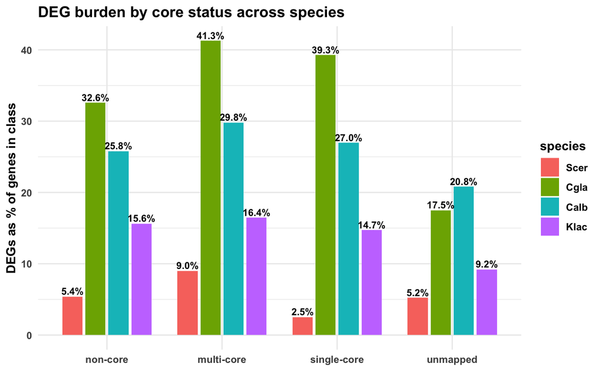

Goal

Build a per-species index of all genes from the reference GTFs, then check which of those genes are represented in our Orthofinder orthogroups table. This tells us which reference genes are covered by orthogroups and which are missing/unmapped What this chunk does (snapshot)

1. Parse the reference GTF into a gene list (gene_id, gene_name). Reads each species’ GTF. Extracts attributes from the attribute column (e.g., gene_id, gene_name, ID, Name). Keeps one row per gene; for Scer drops the gene- prefix so IDs match the rest of the pipeline. Outputs a tidy data frame of all genes in the reference.
2. Explode per-species orthogroup membership. Starts from orthogroups_cleaned. For each species, splits the *_orthgrp_list (semicolon-separated) into one row per gene and keeps its OG. This yields a per-gene ↔︎ OG lookup (e.g., scer_gene_id/qng_id/orf19.*/XP_… → OG).
3. Join GTF gene list to the OG map to flag coverage. Left-join the GTF gene table to the OG map on the appropriate ID type per species (see below). Adds in_orthogroup = TRUE/FALSE. Writes (a) the joined status table and (b) a list of genes present in the reference but not in any OG. Species-specific notes (ID normalization & joins) S. cerevisiae (Scer) GTF IDs: SGD ORFs (Y…). Removes gene- prefix if present. OG join key: scer_gene_id extracted from Scer_orthgrp_list.

Outputs: 06.results/Scer/20250911_scer_missing_from_og.csv (genes not in any OG)

C. glabrata (Cgla) GTF IDs: BG2 locus IDs (e.g., GWK60_*) or CAGL0*. Maps GTF gene IDs → QNG using your Cgla_BG2Protmapping (three-way map). OG join key: qng_id from Cgla_orthgrp_list. Outputs: 06.results/Cgla/20250911_Cgla_missing_from_og.csv (unmapped to OG)

C. albicans (Calb) GTF IDs: Normalized to lower-case; prefers orf19.* where possible. OG join key: lower-case orf19.* from Calb_orthgrp_list. Filters the “missing” table to entries that look like orf19.xxxx to avoid non-coding/misc entries.

Outputs: 06.results/Calb/20250911_Calb_missing_from_og.csv

K. lactis (Klac) GTF IDs: locus tags/gene IDs; protein accessions may appear in protein_id/Dbxref. Extracts XP_… accessions and uses those as the canonical join key. OG join key: xp_id from Klac_orthgrp_list. Full coverage table and a filtered “protein-coding only (has XP_) but missing from OG” list.

```r
# 3) Coverage: join GTF genes to OG map via XP_
klac_gene_og_status <- klac_gene_list %>%
  left_join(klac_og_map, by = "xp_id") %>%
  mutate(in_orthogroup = !is.na(OG))
```

[output not shown]

Goal

Replicate Doughty et al. Fig. 1c for each species: quantify whether DE genes are enriched or depleted within each core-status class (non-core / multi-core / single-core), after normalizing by the genome-wide DE rate.

Inputs Scer_DE_topGo.csv, Cgla_DE_topGo.csv, Calb_DE_topGo.csv, Klac_DE_topGo.csv: full DESeq2 outputs (all genes tested: gene_id, log2FoldChange, padj). orthogroup2: orthology/master table with *_orthgrp_list (IDs per OG) and **core_status (non-core / multi-core / single-core). Mapping tables for species that need them: Cgla: qng_gwk_cagl_threeway_map_complete.csv (GWK60/CAGL0 → QNG). Klac: xp_to_klla0_mapping.csv (locus_tag ↔︎ XP*).

Thresholds / rule used (configurable) fdr_cutoff = 0.01 lfc_thr = 1 use_abs = FALSE → counts “up-regulated only” (log2FC > 1). (Set use_abs = TRUE for |log2FC| > 1, both directions.)

Build a per-gene core-status map (from orthogroup2) “Explode” each species’ *_orthgrp_list into one row per gene ID and keep its *_core_status. Result: small lookup tables (scer_map, cgla_map, calb_map, klac_map): gene_id ↔︎ core_status. Align identifiers & join Scer/Calb: gene_id already matches *_orthgrp_list (SGD ORFs / orf19.*).

Cgla: convert DESeq gene_id (GWK60/CAGL0) → QNG via mapping, then join to cgla_map. Klac: convert DESeq gene_id (locus_tag) → XP_ (or back, depending on files) via mapping, then join to klac_map. Define the analysis universe (denominators) For each species, keep genes with: a known core_status and detected by DESeq (i.e., padj not NA). Count how many such genes fall in each class → n_class. Define DE calls consistently (numerators) Within the same universe, flag DE per gene with:

padj < fdr_cutoff and (log2FC > lfc_thr) if use_abs = FALSE, else (|log2FC| > lfc_thr). Sum DEs inside each class → n_deg.

Normalize to the genome-wide DE rate Compute the overall DE rate across the whole universe: overall_rate = total_DE / total_detected.

For each class: rate_class = n_deg / n_class fold_enrichment = rate_class / overall_rate

Statistics (per class)

Build a 2×2 table: [ n_deg , n_class - n_deg ] [ overall_DE - n_deg, (overall_N - n_class) - …]

Two-sided Fisher’s exact test → p_value. Convert to significance stars for plotting: *** <0.001, ** <0.01, * <0.05.

Outputs Per-species summary tables: fig1c_scer, fig1c_cgla, fig1c_calb, fig1c_klac with status, n_class, n_deg, rate_class, fold_enrichment, p_value, species.

Combined table fig1c_all. Plot object p_fig1c_all: grouped bars of fold_enrichment by status, colored by species, dashed line at 1, significance stars on top.

Why the normalization matters Raw counts can’t be compared directly across classes because classes can have different sizes and detection rates. By dividing each class’s DE rate by the overall DE rate, a fold_enrichment ≈ 1 means “as expected”, >1 means enriched, <1 depleted—independent of class size.

```r
# S. cerevisiae — FULL DESeq results (not subsetted)
scer_full <- read_csv(here("06.results", "Scer", "Scer_DE_topGo.csv"),
                      show_col_types = FALSE) %>%
  mutate(scer_gene_id = gene_id)

#Set thresholds

fdr_cutoff <- 0.01   # instead of alpha
lfc_thr    <- 1
use_abs    <- FALSE

# --- Build per-gene maps directly from orthogroup (explode *_orthgrp_list) --- Build a per-gene mapping from orthogroups to core status
scerMap <- orthogroups_cleaned %>%
  transmute(scer_core_status,
            scer_gene_id = strsplit(replace_na(Scer_orthgrp_list, ""), ";")) %>%
  unnest_longer(scer_gene_id) %>%
  mutate(scer_gene_id = na_if(trimws(scer_gene_id), "")) %>%
  filter(!is.na(scer_gene_id), !is.na(scer_core_status)) %>%
  distinct(scer_gene_id, scer_core_status)

## Join full DESeq table to core status and coerce numeric
full_status_scer <- scer_full %>%
  left_join(scerMap, by = "scer_gene_id") %>%
  mutate(
    padj_num = suppressWarnings(as.double(padj)),
    l2fc_num = suppressWarnings(as.double(log2FoldChange))
  ) %>%
  filter(!is.na(scer_core_status), !is.na(padj_num))   # "detected mRNAs"

## Define DE flags and overall DE rate
is_deg_scer <- (full_status_scer$padj_num < fdr_cutoff) &
  (if (use_abs) abs(full_status_scer$l2fc_num) > lfc_thr else full_status_scer$l2fc_num > lfc_thr)

overall_deg  <- sum(is_deg_scer, na.rm = TRUE)
overall_n    <- nrow(full_status_scer)
overall_rate <- overall_deg / overall_n

## --- Denominators: detected per class (same as before) ---
denoms_scer <- full_status_scer %>%
  dplyr::count(status = scer_core_status, name = "n_class")

## --- Numerators: DE within the SAME universe + SAME rule ---
degs_by_class_scer <- full_status_scer %>%
  mutate(is_deg = (padj_num < fdr_cutoff) &
                   (if (use_abs) abs(l2fc_num) > lfc_thr else l2fc_num > lfc_thr)) %>%
  group_by(status = scer_core_status) %>%
  summarise(n_deg = sum(is_deg, na.rm = TRUE), .groups = "drop")

## --- Enrichment table (Fig. 1c metrics) ---
fig1c_scer <- denoms_scer %>%
  left_join(degs_by_class_scer, by = "status") %>%
  mutate(
    n_deg        = replace_na(n_deg, 0L),
    n_notdeg     = n_class - n_deg,
    n_out_deg    = overall_deg - n_deg,
    n_out_notdeg = (overall_n - n_class) - n_out_deg,
    rate_class     = n_deg / n_class,
    fold_enrichment = rate_class / overall_rate,
    p_value = purrr::pmap_dbl(
      list(n_deg, n_notdeg, n_out_deg, n_out_notdeg),
      ~ fisher.test(matrix(c(..1, ..2, ..3, ..4), nrow = 2))$p.value
    ),
    species = "Scer"
  )

########################
cgla_full <- read_csv(here("06.results", "Cgla", "Cgla_DE_topGo.csv"),
                      show_col_types = FALSE) %>%
  mutate(cgla_gene_id = gene_id)

cglaMap <- orthogroups_cleaned %>%
  transmute(cgla_core_status,
            cgla_gene_id = strsplit(replace_na(Cgla_orthgrp_list, ""), ";")) %>%
  unnest_longer(cgla_gene_id) %>%
  mutate(cgla_gene_id = na_if(trimws(cgla_gene_id), "")) %>%
  filter(!is.na(cgla_gene_id), !is.na(cgla_core_status)) %>%
  distinct(cgla_gene_id, cgla_core_status) %>%
  left_join(Cgla_BG2Protmapping, by = c("cgla_gene_id" = "qng_id"))


## --- Join full DESeq table to core status and coerce numeric ---
full_status_cgla <- cgla_full %>%
  left_join(cglaMap, by = c("gene_id" = "gene_id")) %>%
  mutate(
    padj_num = suppressWarnings(as.double(padj)),
    l2fc_num = suppressWarnings(as.double(log2FoldChange))
  ) %>%
  filter(!is.na(cgla_core_status), !is.na(padj_num))            # detected mRNAs in OGs

## --- Define DE flags and overall DE rate (use the same fdr_cutoff/lfc_thr/use_abs you set) ---
is_deg_cgla <- (full_status_cgla$padj_num < fdr_cutoff) &
  (if (use_abs) abs(full_status_cgla$l2fc_num) > lfc_thr else full_status_cgla$l2fc_num > lfc_thr)

overall_deg_cgla  <- sum(is_deg_cgla, na.rm = TRUE)
overall_n_cgla    <- nrow(full_status_cgla)
overall_rate_cgla <- overall_deg_cgla / overall_n_cgla

## --- Denominators (detected per class) ---
denoms_cgla <- full_status_cgla %>%
  dplyr::count(status = cgla_core_status, name = "n_class")

## --- Numerators (your already-joined DEGs table for Cgla) ---
degs_by_class_cgla <- full_status_cgla %>%
  mutate(is_deg = (padj_num < fdr_cutoff) &
                  (if (use_abs) abs(l2fc_num) > lfc_thr else l2fc_num > lfc_thr)) %>%
  group_by(status = cgla_core_status) %>%
  summarise(n_deg = sum(is_deg, na.rm = TRUE), .groups = "drop")
## --- Enrichment table (Fig. 1c metrics) ---
fig1c_cgla <- denoms_cgla %>%
  left_join(degs_by_class_cgla, by = "status") %>%
  mutate(
    n_deg        = replace_na(n_deg, 0L),
    n_notdeg     = n_class - n_deg,
    n_out_deg    = overall_deg_cgla - n_deg,
    n_out_notdeg = (overall_n_cgla - n_class) - n_out_deg,
    rate_class     = n_deg / n_class,
    fold_enrichment = rate_class / overall_rate_cgla,
    p_value = purrr::pmap_dbl(
      list(n_deg, n_notdeg, n_out_deg, n_out_notdeg),
      ~ fisher.test(matrix(c(..1, ..2, ..3, ..4), nrow = 2))$p.value
    ),
    species = "Cgla"
  )

#############################
########### 1 Full DESeq results for Calb (ALL tested genes)
calb_full <- read_csv(here("06.results", "Calb", "Calb_DE_topGo.csv"),
                      show_col_types = FALSE) %>%
  mutate(calb_gene_id = gene_id)

############# 2 Per-gene core status map from orthogroup2 (explode Calb_orthgrp_list)
calbMap <- orthogroups_cleaned %>%
  transmute(calb_core_status,
            calb_gene_id = strsplit(replace_na(Calb_orthgrp_list, ""), ";")) %>%
  unnest_longer(calb_gene_id) %>%
  mutate(calb_gene_id = na_if(trimws(calb_gene_id), "")) %>%
  filter(!is.na(calb_gene_id), !is.na(calb_core_status)) %>%
  distinct(calb_gene_id, calb_core_status)

# 3) Join full DESeq to core status; coerce numerics; keep detected & mapped
full_status_calb <- calb_full %>%
  left_join(calbMap, by = "calb_gene_id") %>%
  mutate(
    padj_num = suppressWarnings(as.double(padj)),
    l2fc_num = suppressWarnings(as.double(log2FoldChange))
  ) %>%
  filter(!is.na(calb_core_status), !is.na(padj_num))   # detected mRNAs inside OGs

# 4) Overall DE flags/rate (same rule as you use for plotting)
is_deg_calb <- (full_status_calb$padj_num < fdr_cutoff) &
  (if (use_abs) abs(full_status_calb$l2fc_num) > lfc_thr else full_status_calb$l2fc_num > lfc_thr)

overall_deg_calb  <- sum(is_deg_calb, na.rm = TRUE)
overall_n_calb    <- nrow(full_status_calb)
overall_rate_calb <- overall_deg_calb / overall_n_calb

# 5) Denominators per class (detected)
denoms_calb <- full_status_calb %>%
  dplyr::count(status = calb_core_status, name = "n_class")

# 6) Numerators per class (DE within the SAME universe/rule)
degs_by_class_calb <- full_status_calb %>%
  mutate(is_deg = (padj_num < fdr_cutoff) &
                   (if (use_abs) abs(l2fc_num) > lfc_thr else l2fc_num > lfc_thr)) %>%
  group_by(status = calb_core_status) %>%
  summarise(n_deg = sum(is_deg, na.rm = TRUE), .groups = "drop")

# 7) Fig-1c style enrichment table (Calb)
fig1c_calb <- denoms_calb %>%
  left_join(degs_by_class_calb, by = "status") %>%
  mutate(
    n_deg        = replace_na(n_deg, 0L),
    n_notdeg     = n_class - n_deg,
    n_out_deg    = overall_deg_calb - n_deg,
    n_out_notdeg = (overall_n_calb - n_class) - n_out_deg,
    rate_class     = n_deg / n_class,
    fold_enrichment = rate_class / overall_rate_calb,
    p_value = pmap_dbl(
      list(n_deg, n_notdeg, n_out_deg, n_out_notdeg),
      ~ fisher.test(matrix(c(..1, ..2, ..3, ..4), nrow = 2))$p.value
    ),
    species = "Calb"
  )
#####################
########### 1 Full DESeq results for Calb (ALL tested genes)
klac_full <- read_csv(here("06.results", "Klac", "Klac_DE_topGo.csv"),
                      show_col_types = FALSE) %>%
  mutate(klac_gene_id = gene_id)

############# 2 Per-gene core status map from orthogroup2 (explode Calb_orthgrp_list
klacMap <- orthogroups_cleaned %>%
  transmute(klac_core_status,
            klac_gene_id = strsplit(replace_na(Klac_orthgrp_list, ""), ";")) %>%
  unnest_longer(klac_gene_id) %>%
  mutate(klac_gene_id = na_if(trimws(klac_gene_id), "")) %>%
  filter(!is.na(klac_gene_id), !is.na(klac_core_status)) %>%
  distinct(klac_gene_id, klac_core_status) %>%
  left_join(Klac_xpklla0tmapping, by = c("klac_gene_id" = "xp_id"))


## --- Join full DESeq table to core status and coerce numeric ---
full_status_klac <- klac_full %>%
  left_join(klacMap, by = c("gene_id" = "locus_tag")) %>%
  mutate(
    padj_num = suppressWarnings(as.double(padj)),
    l2fc_num = suppressWarnings(as.double(log2FoldChange))
  ) %>%
  filter(!is.na(klac_core_status), !is.na(padj_num))            # detected mRNAs in OGs


# 4) Overall DE flags/rate (same rule you use everywhere)
is_deg_klac <- (full_status_klac$padj_num < fdr_cutoff) &
  (if (use_abs) abs(full_status_klac$l2fc_num) > lfc_thr else full_status_klac$l2fc_num > lfc_thr)

overall_deg_klac  <- sum(is_deg_klac, na.rm = TRUE)
overall_n_klac    <- nrow(full_status_klac)
overall_rate_klac <- overall_deg_klac / overall_n_klac

# 5) Denominators per class
denoms_klac <- full_status_klac %>%
  dplyr::count(status = klac_core_status, name = "n_class")

# 6) Numerators per class (DE within SAME universe/rule)
degs_by_class_klac <- full_status_klac %>%
  mutate(is_deg = (padj_num < fdr_cutoff) &
                   (if (use_abs) abs(l2fc_num) > lfc_thr else l2fc_num > lfc_thr)) %>%
  group_by(status = klac_core_status) %>%
  summarise(n_deg = sum(is_deg, na.rm = TRUE), .groups = "drop")

# 7) Fig-1c style enrichment table
fig1c_klac <- denoms_klac %>%
  left_join(degs_by_class_klac, by = "status") %>%
  mutate(
    n_deg        = replace_na(n_deg, 0L),
    n_notdeg     = n_class - n_deg,
    n_out_deg    = overall_deg_klac - n_deg,
    n_out_notdeg = (overall_n_klac - n_class) - n_out_deg,
    rate_class     = n_deg / n_class,
    fold_enrichment = rate_class / overall_rate_klac,
    p_value = pmap_dbl(
      list(n_deg, n_notdeg, n_out_deg, n_out_notdeg),
      ~ fisher.test(matrix(c(..1, ..2, ..3, ..4), nrow = 2))$p.value
    ),
    species = "Klac"
  )

# Combine and plot
fig1c_all <- bind_rows(fig1c_scer, fig1c_cgla, fig1c_calb, fig1c_klac) %>%
  mutate(
    status  = factor(status, levels = c("non-core","multi-core","single-core")),
    species = factor(species, levels = c("Scer","Cgla","Calb","Klac")),
    sig = case_when(p_value < 0.001 ~ "***",
                    p_value < 0.01  ~ "**",
                    p_value < 0.05  ~ "*",
                    TRUE            ~ "")
  )

p_fig1c_all <- ggplot(fig1c_all, aes(x=status, y=fold_enrichment, fill=species)) +
  geom_hline(yintercept=1, linewidth=0.6, linetype=2) +
  geom_col(position=position_dodge(0.8), width=0.7) +
  geom_text(aes(label=sig),
            position=position_dodge(0.8), vjust=-0.6, size=6, fontface="bold") +
  scale_y_continuous(expand = expansion(mult = c(0.02, 0.15))) +
  coord_cartesian(clip = "off") +
  labs(x=NULL, y="Fold enrichment of DE rate (class / overall)",
       title="Stress adaptation responsive genes in -Pi") +
  theme_minimal() + bold_theme

p_fig1c_all
```

[output not shown]

```r
suppressPackageStartupMessages({
  library(dplyr)
  library(readr)
  library(stringr)
  library(here)
})

# ---- Standardize sample names & write outputs --------------------------------
# Rules:
#  - within each species x timepoint: smallest b# -> b1, next smallest -> b2
#  - L001/L002 -> .1/.2
#  - keep non-count cols (e.g., gene_id, gene_name) untouched
# Writes:
#  - <out_dir>/<species>_renamed_counts.tsv
#  - <out_dir>/<species>_column_mapping.csv
#  - <out_dir>/<species>_collapse_groups.csv  (new_col -> sample_id for collapsing tech reps)
standardize_sample_names <- function(counts_df,
                                     species,
                                     out_dir,
                                     non_count_cols = c("gene_id","gene_name"),
                                     strict = TRUE) {
  stopifnot(is.data.frame(counts_df), is.character(species), length(species) == 1)
  dir.create(out_dir, recursive = TRUE, showWarnings = FALSE)

  old_cols <- colnames(counts_df)

  # Only touch columns that match this species and the pattern Species.tXXXX.b#.L###
  rx <- sprintf("^(%s)\\.(t\\d{4})\\.b(\\d+)\\.L(\\d+)$", species)
  is_count_col <- grepl(rx, old_cols)

  parse <- regexec(rx, old_cols)
  m <- regmatches(old_cols, parse)

  parsed_df <- do.call(rbind, lapply(seq_along(m), function(i) {
    mm <- m[[i]]
    if (length(mm) == 0) return(NULL)
    data.frame(
      old     = old_cols[i],
      species = mm[2],
      tp      = mm[3],
      b_raw   = as.integer(mm[4]),
      L_raw   = mm[5],
      stringsAsFactors = FALSE
    )
  }))

  if (is.null(parsed_df) || nrow(parsed_df) == 0L) {
    if (strict) warning(sprintf("[%s] No columns matched %s; returning input unchanged.", species, rx))
    # Still write out a copy for traceability
    out_counts <- file.path(out_dir, sprintf("%s_renamed_counts.tsv", species))
    write_tsv(counts_df, out_counts)
    return(invisible(list(df = counts_df,
                          mapping = tibble(old = character(), new = character()),
                          collapse_groups = tibble(new = character(), sample_id = character()))))
  }

  # Technical replicate index: last digit in L###
  parsed_df$tech <- as.integer(sub(".*(\\d)$", "\\1", parsed_df$L_raw))
  if (any(is.na(parsed_df$tech))) stop(sprintf("[%s] Could not parse technical replicate from L###.", species))

  # Map b_raw -> b_new (1/2) within each (species,tp)
  mapped <- parsed_df %>%
    group_by(species, tp) %>%
    mutate(
      b_sorted = list(sort(unique(b_raw))),
      n_b      = lengths(b_sorted),
      b_rank   = match(b_raw, b_sorted[[1]]),
      b_new    = case_when(
        n_b == 1 ~ 1L,
        n_b >= 2 ~ pmin(b_rank, 2L),
        TRUE     ~ NA_integer_
      )
    ) %>%
    ungroup()

  # Friendly warning for groups with != 2 bio reps
  weird <- mapped %>%
    group_by(species, tp) %>%
    summarise(n_b = n_distinct(b_raw), .groups = "drop") %>%
    filter(n_b != 2L)
  if (nrow(weird) > 0 && strict) {
    msg <- paste(apply(weird, 1, function(r)
      sprintf("%s %s has %s biological replicate(s)", r[["species"]], r[["tp"]], r[["n_b"]])),
      collapse = "; ")
    warning(sprintf("[%s] %s. Mapping smallest->b1 and next->b2.", species, msg))
  }

  # Compose new standardized names
  mapped$new <- sprintf("%s.%s.b%d.%d", mapped$species, mapped$tp, mapped$b_new, mapped$tech)

  # Collision check
  dup_new <- mapped %>% count(new) %>% filter(n > 1)
  if (nrow(dup_new) > 0L) stop(sprintf("[%s] Name collision after mapping: %s",
                                       species, paste(dup_new$new, collapse = ", ")))

  # Build rename vector
  rename_vec <- setNames(mapped$new, mapped$old)

  # Apply to the data frame
  new_cols <- old_cols
  idx <- match(names(rename_vec), new_cols, nomatch = 0)
  new_cols[idx] <- rename_vec[names(rename_vec)[idx > 0]]
  colnames(counts_df) <- new_cols

  # Build a collapse_groups table: new_col -> sample_id (drop .tech)
  collapse_groups <- mapped %>%
    transmute(new, sample_id = sub("\\.[12]$", "", new)) %>%
    distinct()

  # Write outputs
  out_counts <- file.path(out_dir, sprintf("%s_renamed_counts.tsv", species))
  out_map    <- file.path(out_dir, sprintf("%s_column_mapping.csv", species))
  out_cg     <- file.path(out_dir, sprintf("%s_collapse_groups.csv", species))

  write_tsv(counts_df, out_counts)
  write_csv(mapped %>% select(old, new, species, tp, b_raw, b_new, tech), out_map)
  write_csv(collapse_groups, out_cg)

  invisible(list(df = counts_df,
                 mapping = mapped %>% select(old, new, species, tp, b_raw, b_new, tech),
                 collapse_groups = collapse_groups))
}

# ---- Calls for the four species ------------------------------------------------
# Reads you provided:
# Scer <- read_tsv(here("05.metadata","Scer","salmon.merged.gene_counts.tsv"), show_col_types = FALSE)
# Cgla <- read_tsv(here("05.metadata","Cgla","salmon.merged.gene_counts.tsv"), show_col_types = FALSE)
# Calb <- read_tsv(here("05.metadata","Calb","salmon.merged.gene_counts.tsv"), show_col_types = FALSE)
# Klac <- read_tsv(here("05.metadata","Klac","salmon.merged.gene_counts.tsv"), show_col_types = FALSE)

# Output dirs you defined:
# Scer_results <- here("06.results","Scer")
# Cgla_results <- here("06.results","Cgla")
# Calb_results <- here("06.results","Calb")
# Klac_results <- here("06.results","Klac")
# combined     <- here("06.results","combined")

# Run renaming + writes per species
Scer_std <- standardize_sample_names(Scer, species = "Scer", out_dir = Scer_results)
Cgla_std <- standardize_sample_names(Cgla, species = "Cgla", out_dir = Cgla_results)
Calb_std <- standardize_sample_names(Calb, species = "Calb", out_dir = Calb_results)
Klac_std <- standardize_sample_names(Klac, species = "Klac", out_dir = Klac_results)

# Optional: write a combined mapping log across species
dir.create(combined, recursive = TRUE, showWarnings = FALSE)
bind_rows(
  mutate(Scer_std$mapping, organism = "Scer"),
  mutate(Cgla_std$mapping, organism = "Cgla"),
  mutate(Calb_std$mapping, organism = "Calb"),
  mutate(Klac_std$mapping, organism = "Klac")
) %>%
  select(organism, tp, old, new, b_raw, b_new, tech) %>%
  arrange(organism, tp, new) %>%
  write_csv(file.path(combined, "all_species_column_mapping.csv"))

# Tip for DESeq collapsing later:
# readr::read_csv(file.path(Scer_results, "Scer_collapse_groups.csv")) gives you new_col -> sample_id.
# Use sample_id as the 'groupby' argument to collapse technical replicates after subsetting a contrast.
```